# Enquête de conjoncture dans les services

Auteur

Affiliation

Alain Quartier-la-Tente

LEMNA

Date de publication

1 septembre 2026

# 1 Indicateur synthétique du climat des affaires dans les services

## 1.1 Par graphique

**normal**

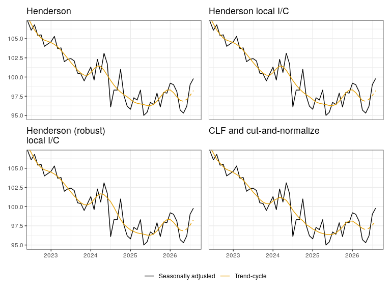

**confint**

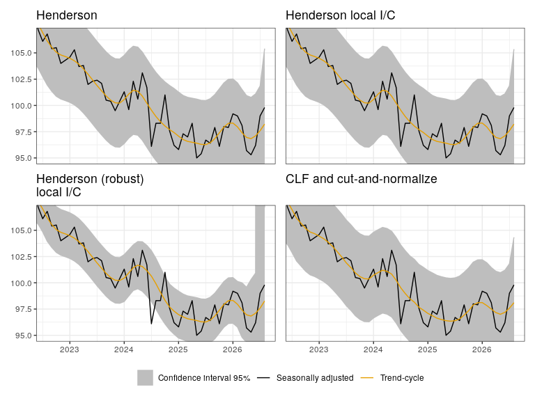

**lollypop**

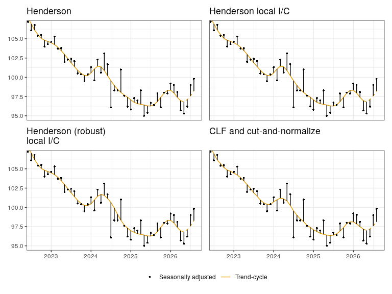

**implicit_forecasts**

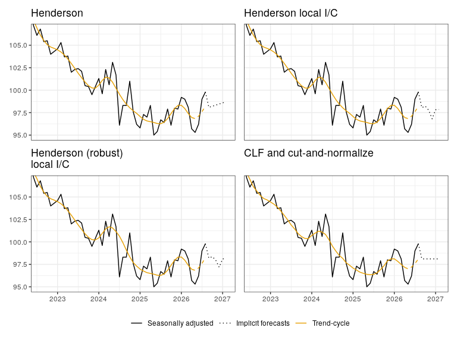

## 1.2 Comparaison des méthodes

**Dernières années**

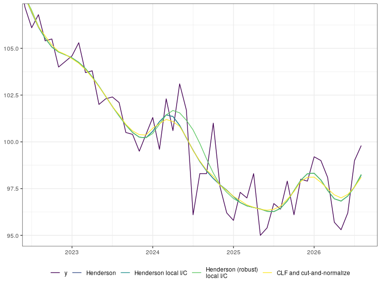

**Ensemble**

[interactive chart not shown]

## 1.3 Analyse des révisions

**Série CVS-CJO**

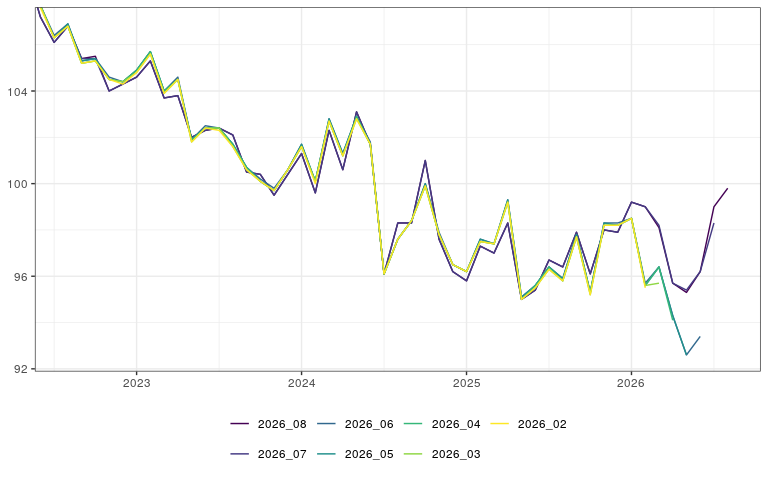

**Henderson**

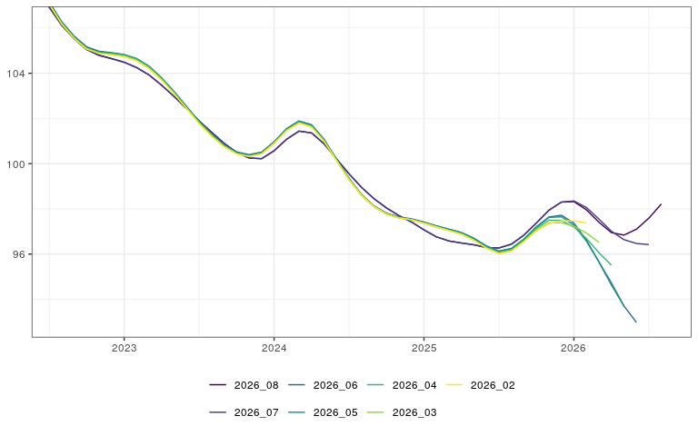

**Henderson local I/C**

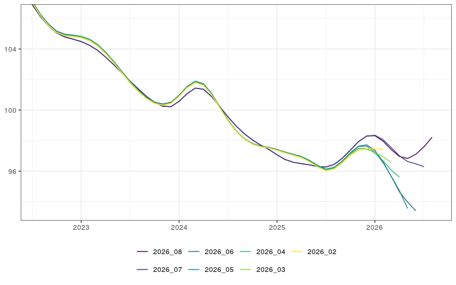

**Henderson (robust) local I/C**

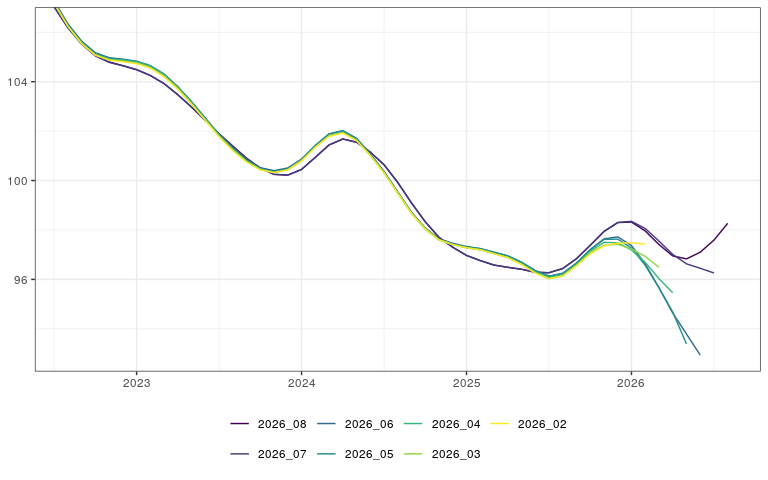

**CLF and cut-and-normalize**

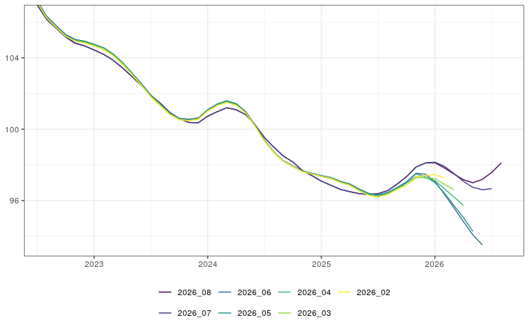

## 1.4 Analyse des révisions

### Révisions

|  | Methods | 2026-08 | 2026-07 | 2026-06 | 2026-05 | 2026-04 | 2026-03 | 2026-02 | 2026-01 | 2025-12 | 2025-11 | 2025-10 | 2025-09 | 2025-08 | 2025-07 | 2025-06 | 2025-05 | 2025-04 | 2025-03 | 2025-02 | 2025-01 | 2024-12 | 2024-11 | 2024-10 | 2024-09 | 2024-08 | 2024-07 | 2024-06 | 2024-05 | … |
| --- | --- | --- | --- | --- | --- | --- | --- | --- | --- | --- | --- | --- | --- | --- | --- | --- | --- | --- | --- | --- | --- | --- | --- | --- | --- | --- | --- | --- | --- | --- |
| 2026-08 | Série CVS-CJO | 99.8 | 99 | 96.2 | 95.3 | 95.7 | 98.1 | 99 | 99.2 | 97.9 | 98 | 96.1 | 97.9 | 96.4 | 96.7 | 95.4 | 95 | 98.3 | 97 | 97.3 | 95.8 | 96.2 | 97.6 | 101 | 98.3 | 98.3 | 96.1 | 101.7 | 103.1 | … |
| 2026-07 | Série CVS-CJO |  | 98.3 | 96.2 | 95.4 | 95.7 | 98.2 | 99 | 99.2 | 97.9 | 98 | 96.1 | 97.9 | 96.4 | 96.7 | 95.4 | 95 | 98.3 | 97 | 97.3 | 95.8 | 96.2 | 97.6 | 101 | 98.3 | 98.3 | 96.1 | 101.7 | 103.1 | … |
| 2026-06 | Série CVS-CJO |  |  | 93.4 | 92.6 | 94.3 | 96.4 | 95.7 | 98.5 | 98.3 | 98.3 | 95.3 | 97.8 | 95.9 | 96.4 | 95.6 | 95.1 | 99.3 | 97.4 | 97.6 | 96.2 | 96.5 | 97.9 | 100 | 98.4 | 97.6 | 96.1 | 101.8 | 102.9 | … |
| 2026-05 | Série CVS-CJO |  |  |  | 92.6 | 94.3 | 96.4 | 95.6 | 98.5 | 98.2 | 98.3 | 95.3 | 97.8 | 95.9 | 96.4 | 95.6 | 95.1 | 99.3 | 97.4 | 97.6 | 96.2 | 96.5 | 97.8 | 100 | 98.4 | 97.6 | 96.1 | 101.7 | 102.9 | … |
| 2026-04 | Série CVS-CJO |  |  |  |  | 94.1 | 96.4 | 95.6 | 98.5 | 98.2 | 98.2 | 95.3 | 97.7 | 95.8 | 96.4 | 95.6 | 95 | 99.2 | 97.4 | 97.5 | 96.2 | 96.5 | 97.8 | 99.9 | 98.4 | 97.6 | 96.1 | 101.7 | 102.9 | … |
| 2026-03 | Série CVS-CJO |  |  |  |  |  | 95.7 | 95.6 | 98.5 | 98.2 | 98.2 | 95.2 | 97.7 | 95.8 | 96.3 | 95.5 | 95 | 99.2 | 97.4 | 97.5 | 96.2 | 96.5 | 97.8 | 99.9 | 98.4 | 97.6 | 96.1 | 101.7 | 102.8 | … |
| 2026-02 | Série CVS-CJO |  |  |  |  |  |  | 95.5 | 98.5 | 98.2 | 98.2 | 95.2 | 97.7 | 95.8 | 96.3 | 95.5 | 95 | 99.2 | 97.4 | 97.5 | 96.2 | 96.5 | 97.8 | 99.9 | 98.4 | 97.6 | 96.1 | 101.7 | 102.8 | … |
| 2026-08 | Henderson | 98.2234581958019 | 97.5933229810253 | 97.1016885522283 | 96.8379642402332 | 96.9534968834057 | 97.40662713393 | 97.9592641105025 | 98.3211836151465 | 98.2971719457014 | 97.9409502262443 | 97.384907120743 | 96.8386163372232 | 96.4448797332698 | 96.2677601809955 | 96.2886639676113 | 96.4081388425816 | 96.4918194808288 | 96.576911169326 | 96.7553941414622 | 97.0718623481781 | 97.4189449869016 | 97.7029173612765 | 98.03883067397 | 98.4480471540843 | 98.9482495832341 | 99.5480054774946 | 100.210270302453 | 100.880953798523 | … |
| 2026-07 | Henderson |  | 96.4151118270585 | 96.472202220052 | 96.6354592881799 | 97.0082993685178 | 97.5470215216007 | 98.0581591489102 | 98.3494641581329 | 98.3009347463682 | 97.9390152417242 | 97.382120743034 | 96.836681352703 | 96.4448797332698 | 96.2677601809955 | 96.2886639676113 | 96.4081388425816 | 96.4918194808288 | 96.576911169326 | 96.7553941414622 | 97.0718623481781 | 97.4189449869016 | 97.7029173612765 | 98.03883067397 | 98.4480471540843 | 98.9482495832341 | 99.5480054774946 | 100.210270302453 | 100.880953798523 | … |
| 2026-06 | Henderson |  |  | 92.9774772810808 | 93.7123109938714 | 94.6434990244967 | 95.6509742740145 | 96.6235939523717 | 97.3723354616479 | 97.7193141224101 | 97.6442248154322 | 97.2078232912598 | 96.6645094070017 | 96.2433079304596 | 96.1308406763515 | 96.3540843057871 | 96.6933079304596 | 96.9485294117647 | 97.0997916170517 | 97.2454334365325 | 97.4193736603953 | 97.5620028578233 | 97.6436651583711 | 97.8132948321029 | 98.1328054298642 | 98.6350142891164 | 99.3472493450821 | 100.201524172422 | 101.075672779233 | … |

[output cut: 25 more lines]

### Révisions à la dernière estimation

|  | Meth | Last date | 2026-07 | 2026-06 | 2026-05 | 2026-04 | 2026-03 | 2026-02 | 2026-01 | 2025-12 | 2025-11 | 2025-10 | 2025-09 | 2025-08 | 2025-07 | 2025-06 | 2025-05 | 2025-04 | 2025-03 | 2025-02 | 2025-01 | 2024-12 | 2024-11 | 2024-10 | 2024-09 | 2024-08 | 2024-07 | 2024-06 | 2024-05 | … |
| --- | --- | --- | --- | --- | --- | --- | --- | --- | --- | --- | --- | --- | --- | --- | --- | --- | --- | --- | --- | --- | --- | --- | --- | --- | --- | --- | --- | --- | --- | --- |
| Due to revisions on SA | CLF and cut-and-normalize | 2026-07 | 0.2289215686274275 | 0.1326249999999476 | 0.063247863247895 | 0.009272183449596128 | -0.01382978723412975 | -0.02960077896790381 | -0.03559999999998809 | -0.006000000000000227 | -0.0003999999999990678 | 0.0006999999999948159 | 0.002700000000004366 | 0 | 0 | 0 | 0 | 0 | 0 | 0 | 0 | 0 | 0 | 0 | 0 | 0 | 0 | 0 | 0 | … |
| Due to update of TC model | CLF and cut-and-normalize | 2026-07 | 0.681039215686269 | 0.4438162393162486 | 0.2002489326891066 | 0.0813811949065979 | -0.01560619558196663 | -0.05166806231740395 | 0 | 0 | 0 | 0 | 0 | 0 | 0 | 0 | 0 | 0 | 0 | 0 | 0 | 0 | 0 | 0 | 0 | 0 | 0 | 0 | 0 | … |
| Total | CLF and cut-and-normalize | 2026-07 | 0.9099607843136965 | 0.5764412393161962 | 0.2634967959370016 | 0.09065337835619403 | -0.02943598281609638 | -0.08126884128530776 | -0.03559999999998809 | -0.006000000000000227 | -0.0003999999999990678 | 0.0006999999999948159 | 0.002700000000004366 | 0 | 0 | 0 | 0 | 0 | 0 | 0 | 0 | 0 | 0 | 0 | 0 | 0 | 0 | 0 | 0 | … |
| Due to revisions on SA | CLF and cut-and-normalize | 2026-06 |  | 2.52826797385616 | 2.349125000000015 | 2.121153846153874 | 1.864406779660968 | 1.532495164410093 | 1.066601752677656 | 0.6315000000000026 | 0.3547999999999973 | 0.2963000000000022 | 0.1940000000000026 | 0.1154999999999973 | 0.0852999999999895 | -0.05599999999999739 | -0.2448000000000121 | -0.4337000000000018 | -0.445999999999998 | -0.4301999999999992 | -0.315400000000011 | -0.1376000000000062 | 0.0157999999999987 | 0.2112999999999943 | 0.2546999999999997 | 0.2506000000000057 | 0.1488999999999976 | 0.008899999999997021 | -0.1650999999999954 | … |
| Due to update of TC model | CLF and cut-and-normalize | 2026-06 |  | 1.136375062845644 | 0.5738675224326926 | 0.218420291292631 | 0.03043488813013084 | -0.05920715667309651 | -0.02325890944494802 | 0 | 0 | 0 | 0 | 0 | 0 | 0 | 0 | 0 | 0 | 0 | 0 | 0 | 0 | 0 | 0 | 0 | 0 | 0 | 0 | … |
| Total | CLF and cut-and-normalize | 2026-06 |  | 3.664643036701804 | 2.922992522432708 | 2.339574137446505 | 1.894841667791098 | 1.473288007736997 | 1.043342843232708 | 0.6315000000000026 | 0.3547999999999973 | 0.2963000000000022 | 0.1940000000000026 | 0.1154999999999973 | 0.0852999999999895 | -0.05599999999999739 | -0.2448000000000121 | -0.4337000000000018 | -0.445999999999998 | -0.4301999999999992 | -0.315400000000011 | -0.1376000000000062 | 0.0157999999999987 | 0.2112999999999943 | 0.2546999999999997 | 0.2506000000000057 | 0.1488999999999976 | 0.008899999999997021 | -0.1650999999999954 | … |
| Due to revisions on SA | CLF and cut-and-normalize | 2026-05 |  |  | 2.220424836601353 | 2.026624999999996 | 1.824679487179438 | 1.529212362911238 | 1.114700193423573 | 0.7235637779941584 | 0.3803000000000054 | 0.3130000000000024 | 0.2000000000000028 | 0.1158999999999963 | 0.08459999999999468 | -0.05869999999998754 | -0.2475000000000023 | -0.4344000000000108 | -0.4429000000000087 | -0.4235000000000042 | -0.3018000000000001 | -0.1215000000000117 | 0.03749999999999432 | 0.2331999999999965 | 0.2749999999999915 | 0.2708999999999975 | 0.1707999999999998 | 0.03059999999999263 | -0.1516999999999911 | … |
| Due to update of TC model | CLF and cut-and-normalize | 2026-05 |  |  | 0.5036363132823567 | 0.09117456479690134 | -0.06006572541383548 | -0.1115612163509354 | -0.01013520309476235 | 0.05012745861733947 | 0 | 0 | 0 | 0 | 0 | 0 | 0 | 0 | 0 | 0 | 0 | 0 | 0 | 0 | 0 | 0 | 0 | 0 | 0 | … |
| Total | CLF and cut-and-normalize | 2026-05 |  |  | 2.72406114988371 | 2.117799564796897 | 1.764613761765602 | 1.417651146560303 | 1.104564990328811 | 0.7736912366114979 | 0.3803000000000054 | 0.3130000000000024 | 0.2000000000000028 | 0.1158999999999963 | 0.08459999999999468 | -0.05869999999998754 | -0.2475000000000023 | -0.4344000000000108 | -0.4429000000000087 | -0.4235000000000042 | -0.3018000000000001 | -0.1215000000000117 | 0.03749999999999432 | 0.2331999999999965 | 0.2749999999999915 | 0.2708999999999975 | 0.1707999999999998 | 0.03059999999999263 | -0.1516999999999911 | … |
| Due to revisions on SA | CLF and cut-and-normalize | 2026-04 |  |  |  | 1.891830065359471 | 1.723374999999947 | 1.477991452991446 | 1.09501495513463 | 0.7705996131527826 | 0.4788704965920374 | 0.355400000000003 | 0.2571999999999974 | 0.1709000000000032 | 0.1396999999999906 | -0.00359999999999161 | -0.1925000000000097 | -0.3799000000000063 | -0.3958000000000084 | -0.3803999999999945 | -0.2665000000000077 | -0.09190000000000964 | 0.059599999999989 | 0.2532999999999959 | 0.2896999999999963 | 0.2841999999999985 | 0.1846000000000032 | 0.05329999999999302 | -0.1169000000000011 | … |

[output cut: 62 more lines]

## 1.5 Statistiques générales

|  | I/C ratio | MCD | Length |
| --- | --- | --- | --- |
| Henderson | 2.19 | 4 | 13 |
| Henderson local I/C | 2.18 | 4 | 13 |
| Henderson (robust) local I/C | 1.22 | 2 | 13 |
| CLF and cut-and-normalize | 2.45 | 4 | 13 |

**Outliers**:

- *Additive outlier* (AO) : April 2020, June 2020, July 2020, November 2020, February 2021, February 2022, and July 2024
- *Level shift* (LS): March 2020, April 2020, June 2020, October 2020, May 2021, June 2021, and December 2021

# 2 Indicateur synthétique du climat des affaires dans le transport (H)

## 2.1 Par graphique

**normal**

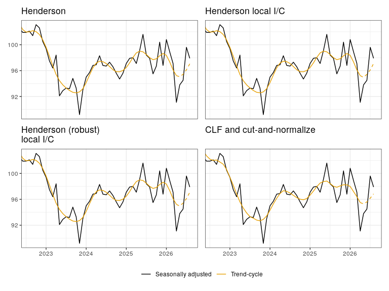

**confint**

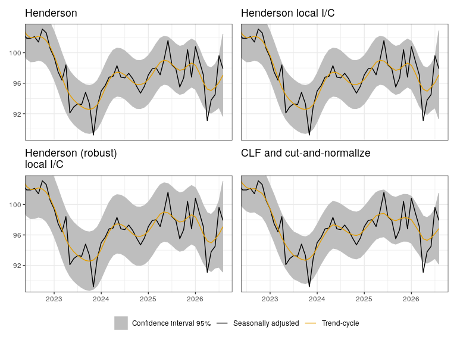

**lollypop**

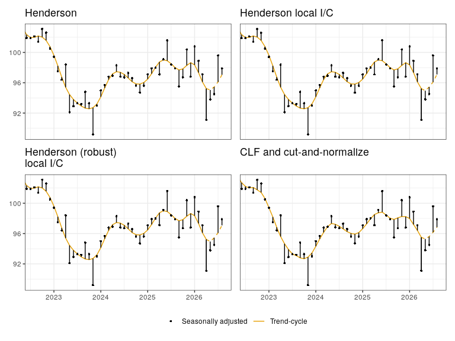

**implicit_forecasts**

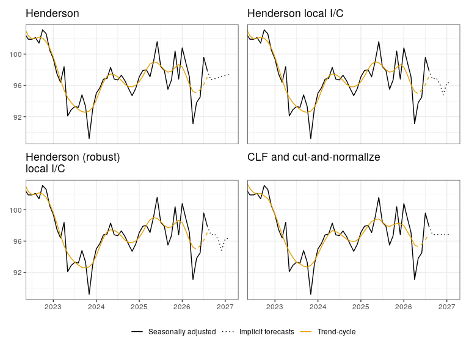

## 2.2 Comparaison des méthodes

**Dernières années**

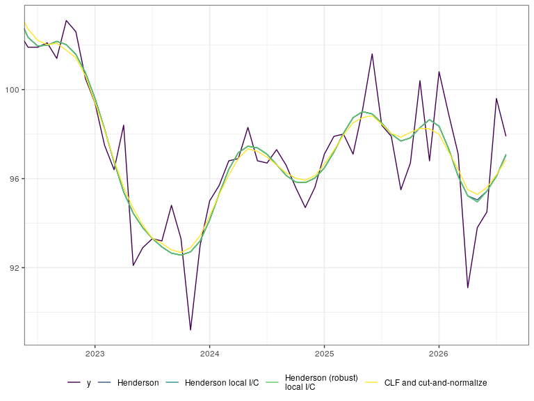

**Ensemble**

[interactive chart not shown]

## 2.3 Analyse des révisions

**Série CVS-CJO**

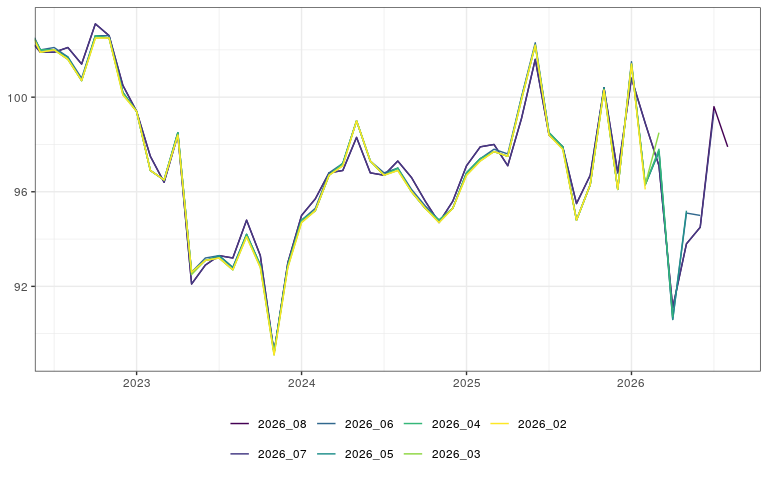

**Henderson**

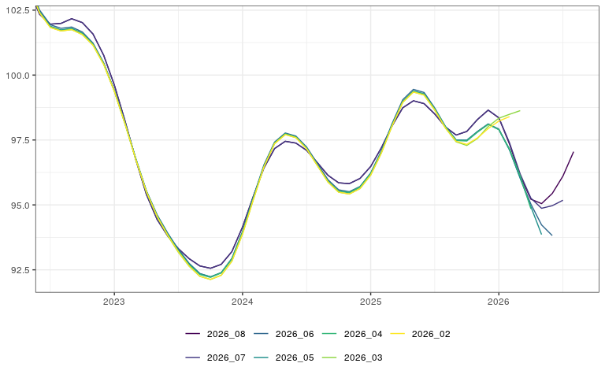

**Henderson local I/C**

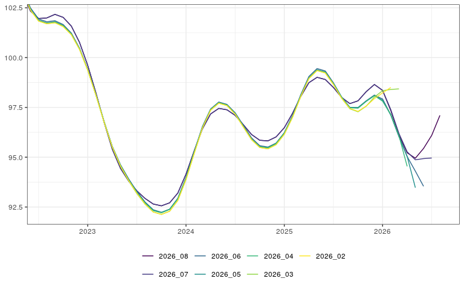

**Henderson (robust) local I/C**

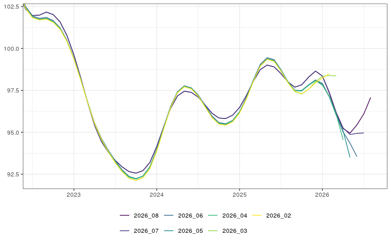

**CLF and cut-and-normalize**

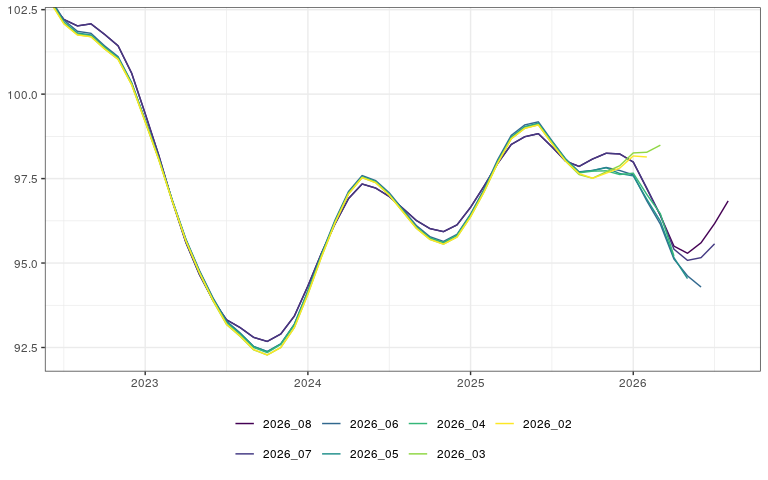

## 2.4 Analyse des révisions

### Révisions

|  | Methods | 2026-08 | 2026-07 | 2026-06 | 2026-05 | 2026-04 | 2026-03 | 2026-02 | 2026-01 | 2025-12 | 2025-11 | 2025-10 | 2025-09 | 2025-08 | 2025-07 | 2025-06 | 2025-05 | 2025-04 | 2025-03 | 2025-02 | 2025-01 | 2024-12 | 2024-11 | 2024-10 | 2024-09 | 2024-08 | 2024-07 | 2024-06 | 2024-05 | … |
| --- | --- | --- | --- | --- | --- | --- | --- | --- | --- | --- | --- | --- | --- | --- | --- | --- | --- | --- | --- | --- | --- | --- | --- | --- | --- | --- | --- | --- | --- | --- |
| 2026-08 | Série CVS-CJO | 97.9 | 99.6 | 94.5 | 93.8 | 91.1 | 97.1 | 98.9 | 100.8 | 96.8 | 100.4 | 96.7 | 95.5 | 97.9 | 98.4 | 101.6 | 99.1 | 97.1 | 98 | 97.9 | 97.1 | 95.6 | 94.7 | 95.6 | 96.6 | 97.3 | 96.7 | 96.8 | 98.3 | … |
| 2026-07 | Série CVS-CJO |  | 99.4 | 94.5 | 93.8 | 91.1 | 97.1 | 98.9 | 100.8 | 96.8 | 100.4 | 96.7 | 95.5 | 97.9 | 98.4 | 101.6 | 99.1 | 97.1 | 98 | 97.9 | 97.1 | 95.6 | 94.7 | 95.6 | 96.6 | 97.3 | 96.7 | 96.8 | 98.3 | … |
| 2026-06 | Série CVS-CJO |  |  | 95 | 95.1 | 90.6 | 97.7 | 96.3 | 101.5 | 96.1 | 100.4 | 96.3 | 94.8 | 97.9 | 98.5 | 102.3 | 100 | 97.6 | 97.8 | 97.4 | 96.8 | 95.3 | 94.8 | 95.4 | 96.1 | 97 | 96.8 | 97.3 | 99 | … |
| 2026-05 | Série CVS-CJO |  |  |  | 95.2 | 90.6 | 97.7 | 96.3 | 101.4 | 96.1 | 100.4 | 96.3 | 94.8 | 97.9 | 98.5 | 102.2 | 100 | 97.5 | 97.7 | 97.4 | 96.8 | 95.3 | 94.8 | 95.3 | 96 | 97 | 96.7 | 97.3 | 99 | … |
| 2026-04 | Série CVS-CJO |  |  |  |  | 90.7 | 97.8 | 96.3 | 101.4 | 96.1 | 100.3 | 96.3 | 94.8 | 97.9 | 98.5 | 102.2 | 99.9 | 97.5 | 97.7 | 97.4 | 96.8 | 95.3 | 94.8 | 95.3 | 96 | 97 | 96.7 | 97.3 | 99 | … |
| 2026-03 | Série CVS-CJO |  |  |  |  |  | 98.5 | 96.3 | 101.4 | 96.1 | 100.3 | 96.3 | 94.8 | 97.8 | 98.4 | 102.2 | 99.9 | 97.5 | 97.7 | 97.3 | 96.7 | 95.3 | 94.7 | 95.3 | 96 | 96.9 | 96.7 | 97.3 | 99 | … |
| 2026-02 | Série CVS-CJO |  |  |  |  |  |  | 96.1 | 101.4 | 96.1 | 100.3 | 96.3 | 94.8 | 97.8 | 98.4 | 102.2 | 99.9 | 97.5 | 97.7 | 97.3 | 96.7 | 95.3 | 94.7 | 95.3 | 96 | 96.9 | 96.7 | 97.3 | 99 | … |
| 2026-08 | Henderson | 97.0529188556669 | 96.1113276057489 | 95.4375654723732 | 95.0467902426026 | 95.2239700547698 | 96.1063005726582 | 97.3407656584901 | 98.3534710645392 | 98.6488151940938 | 98.28883067397 | 97.8298582995951 | 97.6869790426292 | 98.0005298880686 | 98.4952786377709 | 98.9024886877828 | 99.0091271731364 | 98.7359252202906 | 98.0388485353656 | 97.1960764467731 | 96.4823172183853 | 96.0227018337699 | 95.8191057394618 | 95.8459335556085 | 96.1425220290545 | 96.6312455346511 | 97.0957966182424 | 97.3808049535604 | 97.4545010716837 | … |
| 2026-07 | Henderson |  | 95.1824206949546 | 94.9711961967709 | 94.8741057002689 | 95.2616600502236 | 96.1854370185971 | 97.3903734125678 | 98.3573410335794 | 98.6488151940938 | 98.28883067397 | 97.8298582995951 | 97.6869790426292 | 98.0005298880686 | 98.4952786377709 | 98.9024886877828 | 99.0091271731364 | 98.7359252202906 | 98.0388485353656 | 97.1960764467731 | 96.4823172183853 | 96.0227018337699 | 95.8191057394618 | 95.8459335556085 | 96.1425220290545 | 96.6312455346511 | 97.0957966182424 | 97.3808049535604 | 97.4545010716837 | … |
| 2026-06 | Henderson |  |  | 93.8223929446752 | 94.2253101204309 | 95.0255084085334 | 96.0299560094737 | 97.1257450935874 | 97.9225616093605 | 98.1199630864491 | 97.8346391998095 | 97.4912479161705 | 97.4987139795189 | 98.0211300309598 | 98.7310371517028 | 99.3273100738271 | 99.4524708263872 | 99.0506906406287 | 98.1342402953084 | 97.0807930459633 | 96.2287270778757 | 95.7077399380805 | 95.5068409145035 | 95.5812633960467 | 95.9673374613003 | 96.5958680638247 | 97.2278697308883 | 97.6500833531793 | 97.7693260300072 | … |

[output cut: 25 more lines]

### Révisions à la dernière estimation

|  | Meth | Last date | 2026-07 | 2026-06 | 2026-05 | 2026-04 | 2026-03 | 2026-02 | 2026-01 | 2025-12 | 2025-11 | 2025-10 | 2025-09 | 2025-08 | 2025-07 | 2025-06 | 2025-05 | 2025-04 | 2025-03 | 2025-02 | 2025-01 | 2024-12 | 2024-11 | 2024-10 | 2024-09 | 2024-08 | 2024-07 | 2024-06 | 2024-05 | … |
| --- | --- | --- | --- | --- | --- | --- | --- | --- | --- | --- | --- | --- | --- | --- | --- | --- | --- | --- | --- | --- | --- | --- | --- | --- | --- | --- | --- | --- | --- | --- |
| Due to revisions on SA | CLF and cut-and-normalize | 2026-07 | 0.07320261437911313 | 0.04699999999995441 | 0.02905982905983251 | 0.01335992023925314 | 0.00599613152802192 | -0.001363193768284532 | -0.00539999999999452 | 0 | 0 | 0 | 0 | 0 | 0 | 0 | 0 | 0 | 0 | 0 | 0 | 0 | 0 | 0 | 0 | 0 | 0 | 0 | 0 | … |
| Due to update of TC model | CLF and cut-and-normalize | 2026-07 | 0.5305547385620883 | 0.3906367521367429 | 0.1867320048401666 | 0.07418344579414793 | -0.01009145715582349 | -0.01841626095421134 | 0 | 0 | 0 | 0 | 0 | 0 | 0 | 0 | 0 | 0 | 0 | 0 | 0 | 0 | 0 | 0 | 0 | 0 | 0 | 0 | 0 | … |
| Total | CLF and cut-and-normalize | 2026-07 | 0.6037573529412015 | 0.4376367521366973 | 0.2157918338999991 | 0.08754336603340107 | -0.004095325627801571 | -0.01977945472249587 | -0.00539999999999452 | 0 | 0 | 0 | 0 | 0 | 0 | 0 | 0 | 0 | 0 | 0 | 0 | 0 | 0 | 0 | 0 | 0 | 0 | 0 | 0 | … |
| Due to revisions on SA | CLF and cut-and-normalize | 2026-06 |  | -0.4281045751634736 | -0.2814999999999941 | 0.004700854700828927 | 0.1675972083749144 | 0.3927466150869776 | 0.418597857838364 | 0.4976000000000056 | 0.4200999999999908 | 0.3322000000000003 | 0.1649000000000029 | -0.06230000000000757 | -0.179300000000012 | -0.3537000000000035 | -0.3512999999999948 | -0.2685000000000031 | -0.1036000000000001 | 0.08540000000000703 | 0.2069000000000045 | 0.2801000000000045 | 0.2873000000000019 | 0.2400999999999982 | 0.1462000000000074 | 0.0216000000000065 | -0.115399999999994 | -0.2218000000000018 | -0.2516000000000105 | … |
| Due to update of TC model | CLF and cut-and-normalize | 2026-06 |  | 1.73873805932628 | 0.9509510219341877 | 0.3729903370860796 | 0.08821102418158944 | -0.03454255319147137 | -0.04235608568646398 | 0 | 0 | 0 | 0 | 0 | 0 | 0 | 0 | 0 | 0 | 0 | 0 | 0 | 0 | 0 | 0 | 0 | 0 | 0 | 0 | … |
| Total | CLF and cut-and-normalize | 2026-06 |  | 1.310633484162807 | 0.6694510219341936 | 0.3776911917869086 | 0.2558082325565039 | 0.3582040618955062 | 0.3762417721519 | 0.4976000000000056 | 0.4200999999999908 | 0.3322000000000003 | 0.1649000000000029 | -0.06230000000000757 | -0.179300000000012 | -0.3537000000000035 | -0.3512999999999948 | -0.2685000000000031 | -0.1036000000000001 | 0.08540000000000703 | 0.2069000000000045 | 0.2801000000000045 | 0.2873000000000019 | 0.2400999999999982 | 0.1462000000000074 | 0.0216000000000065 | -0.115399999999994 | -0.2218000000000018 | -0.2516000000000105 | … |
| Due to revisions on SA | CLF and cut-and-normalize | 2026-05 |  |  | -0.2459150326797328 | 0.07537499999999397 | 0.2153846153846217 | 0.4324027916250799 | 0.4310444874274992 | 0.4877312560857376 | 0.4356999999999971 | 0.3393000000000086 | 0.1713000000000022 | -0.04700000000001125 | -0.1534000000000049 | -0.311000000000007 | -0.3001000000000005 | -0.216399999999993 | -0.05910000000000082 | 0.1233000000000004 | 0.2335999999999956 | 0.3068000000000097 | 0.3252000000000095 | 0.2845999999999975 | 0.1955999999999989 | 0.06940000000000168 | -0.07030000000000314 | -0.183400000000006 | -0.2152999999999992 | … |
| Due to update of TC model | CLF and cut-and-normalize | 2026-05 |  |  | 0.9999861526531362 | 0.2664315764023115 | -0.04214811208481706 | -0.1190443668992742 | -0.01845009671180264 | 0.09815433300876464 | 0 | 0 | 0 | 0 | 0 | 0 | 0 | 0 | 0 | 0 | 0 | 0 | 0 | 0 | 0 | 0 | 0 | 0 | 0 | … |
| Total | CLF and cut-and-normalize | 2026-05 |  |  | 0.7540711199734034 | 0.3418065764023055 | 0.1732365032998047 | 0.3133584247258057 | 0.4125943907156966 | 0.5858855890945023 | 0.4356999999999971 | 0.3393000000000086 | 0.1713000000000022 | -0.04700000000001125 | -0.1534000000000049 | -0.311000000000007 | -0.3001000000000005 | -0.216399999999993 | -0.05910000000000082 | 0.1233000000000004 | 0.2335999999999956 | 0.3068000000000097 | 0.3252000000000095 | 0.2845999999999975 | 0.1955999999999989 | 0.06940000000000168 | -0.07030000000000314 | -0.183400000000006 | -0.2152999999999992 | … |
| Due to revisions on SA | CLF and cut-and-normalize | 2026-04 |  |  |  | 0.4601307189542041 | 0.4423750000000126 | 0.5361111111110688 | 0.4809571286141221 | 0.4836557059961564 | 0.4042843232716535 | 0.3607999999999976 | 0.1907000000000068 | -0.03360000000000696 | -0.1367000000000047 | -0.292900000000003 | -0.2804000000000002 | -0.1975999999999942 | -0.04550000000000409 | 0.1300000000000097 | 0.236699999999999 | 0.3061000000000007 | 0.3225000000000051 | 0.2845999999999975 | 0.1955999999999989 | 0.06940000000000168 | -0.07030000000000314 | -0.183400000000006 | -0.2152999999999992 | … |

[output cut: 62 more lines]

## 2.5 Statistiques générales

|  | I/C ratio | MCD | Length |
| --- | --- | --- | --- |
| Henderson | 2.47 | 4 | 13 |
| Henderson local I/C | 2.46 | 4 | 13 |
| Henderson (robust) local I/C | 2.72 | 4 | 13 |
| CLF and cut-and-normalize | 2.80 | 4 | 13 |

**Outliers**:

- *Additive outlier* (AO) : April 2020, May 2020, August 2020, and November 2020
- *Level shift* (LS): March 2020 and May 2021

# 3 Indicateur synthétique du climat des affaires dans l’hébergement-restauration (I)

## 3.1 Par graphique

**normal**

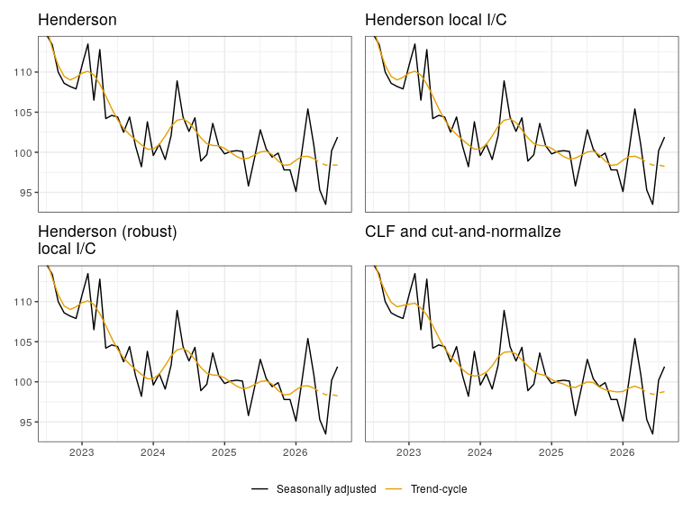

**confint**

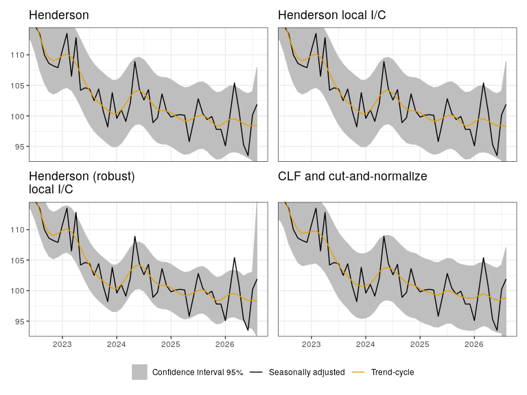

**lollypop**

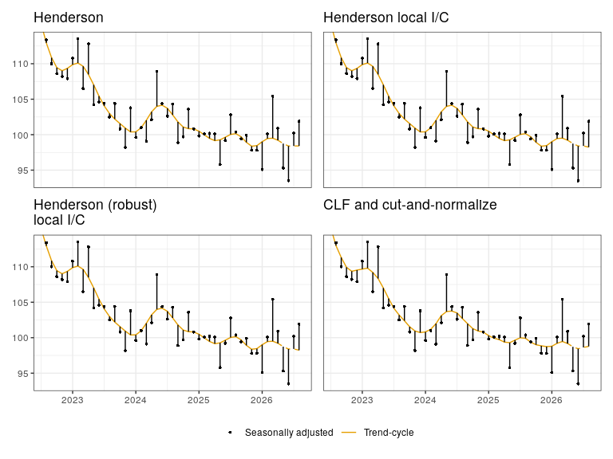

**implicit_forecasts**

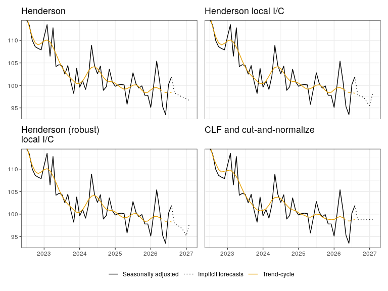

## 3.2 Comparaison des méthodes

**Dernières années**

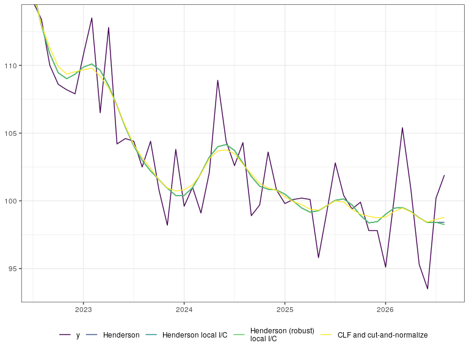

**Ensemble**

[interactive chart not shown]

## 3.3 Analyse des révisions

**Série CVS-CJO**

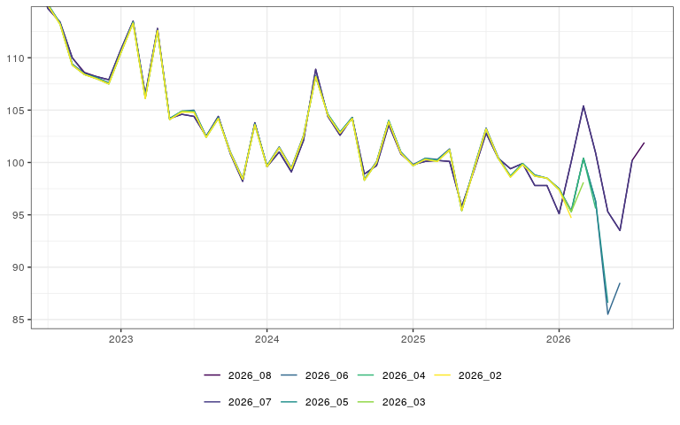

**Henderson**

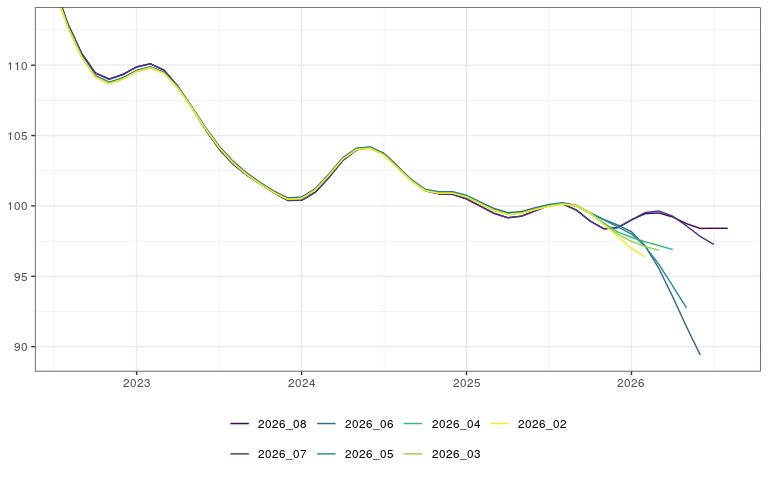

**Henderson local I/C**

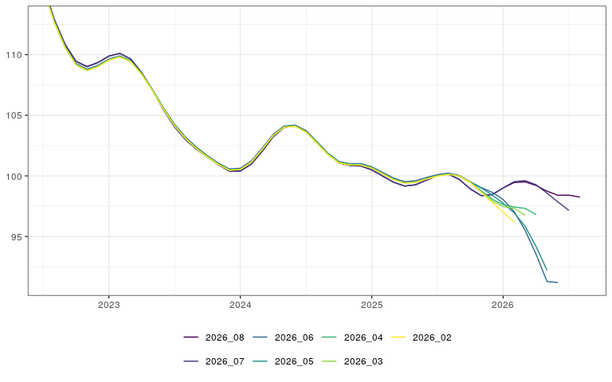

**Henderson (robust) local I/C**

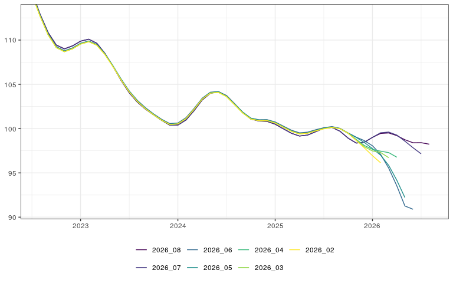

**CLF and cut-and-normalize**

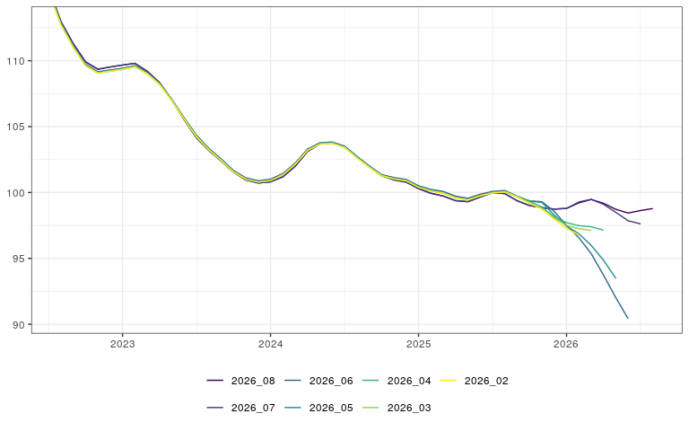

## 3.4 Analyse des révisions

### Révisions

|  | Methods | 2026-08 | 2026-07 | 2026-06 | 2026-05 | 2026-04 | 2026-03 | 2026-02 | 2026-01 | 2025-12 | 2025-11 | 2025-10 | 2025-09 | 2025-08 | 2025-07 | 2025-06 | 2025-05 | 2025-04 | 2025-03 | 2025-02 | 2025-01 | 2024-12 | 2024-11 | 2024-10 | 2024-09 | 2024-08 | 2024-07 | 2024-06 | 2024-05 | … |
| --- | --- | --- | --- | --- | --- | --- | --- | --- | --- | --- | --- | --- | --- | --- | --- | --- | --- | --- | --- | --- | --- | --- | --- | --- | --- | --- | --- | --- | --- | --- |
| 2026-08 | Série CVS-CJO | 101.9 | 100.2 | 93.5 | 95.3 | 100.9 | 105.4 | 100.1 | 95.1 | 97.8 | 97.8 | 99.9 | 99.4 | 100.4 | 102.8 | 99.2 | 95.8 | 100.1 | 100.2 | 100.1 | 99.8 | 100.8 | 103.6 | 99.7 | 98.9 | 104.3 | 102.6 | 104.4 | 108.9 | … |
| 2026-07 | Série CVS-CJO |  | 100.2 | 93.5 | 95.3 | 100.9 | 105.4 | 100.1 | 95.1 | 97.8 | 97.8 | 99.9 | 99.4 | 100.4 | 102.8 | 99.2 | 95.8 | 100.1 | 100.2 | 100.1 | 99.8 | 100.9 | 103.6 | 99.7 | 98.9 | 104.3 | 102.6 | 104.4 | 108.9 | … |
| 2026-06 | Série CVS-CJO |  |  | 88.5 | 85.5 | 96.3 | 100.4 | 95.4 | 97.5 | 98.5 | 98.8 | 99.9 | 98.7 | 100.5 | 103.3 | 99.5 | 95.5 | 101.3 | 100.3 | 100.4 | 99.8 | 101 | 104 | 100.1 | 98.4 | 104.3 | 102.9 | 104.6 | 108.3 | … |
| 2026-05 | Série CVS-CJO |  |  |  | 86.6 | 96.3 | 100.4 | 95.3 | 97.5 | 98.5 | 98.8 | 99.9 | 98.7 | 100.4 | 103.2 | 99.4 | 95.4 | 101.2 | 100.2 | 100.4 | 99.7 | 101 | 104 | 100 | 98.4 | 104.3 | 102.9 | 104.6 | 108.2 | … |
| 2026-04 | Série CVS-CJO |  |  |  |  | 95.6 | 100.4 | 95.3 | 97.4 | 98.5 | 98.7 | 99.9 | 98.7 | 100.4 | 103.2 | 99.4 | 95.4 | 101.2 | 100.2 | 100.3 | 99.7 | 100.9 | 104 | 100 | 98.3 | 104.2 | 102.9 | 104.6 | 108.2 | … |
| 2026-03 | Série CVS-CJO |  |  |  |  |  | 98.1 | 95.3 | 97.4 | 98.5 | 98.7 | 99.8 | 98.6 | 100.4 | 103.2 | 99.4 | 95.4 | 101.2 | 100.1 | 100.3 | 99.7 | 100.9 | 103.9 | 100 | 98.3 | 104.2 | 102.8 | 104.5 | 108.2 | … |
| 2026-02 | Série CVS-CJO |  |  |  |  |  |  | 94.7 | 97.4 | 98.5 | 98.7 | 99.8 | 98.6 | 100.4 | 103.2 | 99.3 | 95.4 | 101.2 | 100.1 | 100.3 | 99.7 | 100.9 | 103.9 | 100 | 98.3 | 104.2 | 102.8 | 104.5 | 108.2 | … |
| 2026-08 | Henderson | 98.41031314671 | 98.4059068272129 | 98.3978652995803 | 98.7406970894205 | 99.2103780245425 | 99.5039339597761 | 99.4543581805192 | 99.0094665396523 | 98.4586389616575 | 98.3706120504882 | 98.9202905453679 | 99.6982733984282 | 100.142885210764 | 100.036312217195 | 99.6493272207668 | 99.2699452250536 | 99.1579364134318 | 99.4726184805906 | 99.9790188140033 | 100.489735651346 | 100.80729935699 | 100.851643248392 | 101.076393188854 | 101.799696356275 | 102.785925220291 | 103.717599428435 | 104.155048821148 | 103.994957132651 | … |
| 2026-07 | Henderson |  | 97.2594294849936 | 97.834676745464 | 98.5795068433196 | 99.2749845578923 | 99.6351829419288 | 99.5322326572171 | 99.0094665396523 | 98.4586389616575 | 98.3706120504882 | 98.9202905453679 | 99.6982733984282 | 100.142885210764 | 100.036312217195 | 99.6473922362467 | 99.2671588473446 | 99.1579364134318 | 99.4791676589664 | 99.9937544653489 | 100.51116932603 | 100.831305072636 | 100.873076923077 | 101.0911288402 | 101.806245534651 | 102.785925220291 | 103.714813050726 | 104.153113836628 | 103.994957132651 | … |
| 2026-06 | Henderson |  |  | 89.4096264895698 | 91.4202470985639 | 93.5372053951175 | 95.5365270310181 | 97.1618337299725 | 98.1606889233347 | 98.6396225291736 | 99.0251964753513 | 99.5058704453441 | 100.030531078828 | 100.22955465587 | 100.099005715647 | 99.871201476542 | 99.6013812812574 | 99.5249166468207 | 99.8159561800429 | 100.283382948321 | 100.751530126221 | 101.008323410336 | 101.000643010241 | 101.181138366278 | 101.86278280543 | 102.791748035246 | 103.707894736842 | 104.190021433675 | 104.114949988092 | … |

[output cut: 25 more lines]

### Révisions à la dernière estimation

|  | Meth | Last date | 2026-07 | 2026-06 | 2026-05 | 2026-04 | 2026-03 | 2026-02 | 2026-01 | 2025-12 | 2025-11 | 2025-10 | 2025-09 | 2025-08 | 2025-07 | 2025-06 | 2025-05 | 2025-04 | 2025-03 | 2025-02 | 2025-01 | 2024-12 | 2024-11 | 2024-10 | 2024-09 | 2024-08 | 2024-07 | 2024-06 | 2024-05 | … |
| --- | --- | --- | --- | --- | --- | --- | --- | --- | --- | --- | --- | --- | --- | --- | --- | --- | --- | --- | --- | --- | --- | --- | --- | --- | --- | --- | --- | --- | --- | --- |
| Due to revisions on SA | CLF and cut-and-normalize | 2026-07 | 2.842170943040401e-14 | 4.263256414560601e-14 | -4.263256414560601e-14 | 0 | 2.842170943040401e-14 | 0 | 0 | 0 | 0 | 0 | 0 | 0 | 0 | 0.002700000000004366 | 0.0006999999999948159 | -0.003099999999989222 | -0.006700000000009254 | -0.01359999999999673 | -0.01879999999999882 | -0.02240000000000464 | -0.01879999999999882 | -0.01359999999999673 | -0.006699999999995043 | -0.003099999999989222 | 0.0006999999999948159 | 0.002700000000004366 | 0 | … |
| Due to update of TC model | CLF and cut-and-normalize | 2026-07 | 1.006007352941168 | 0.5886431623931685 | 0.2278608618588436 | 0.08393089590030911 | -0.01648357029453962 | -0.07063115871470416 | 0 | 0 | 0 | 0 | 0 | 0 | 0 | 0 | 0 | 0 | 0 | 0 | 0 | 0 | 0 | 0 | 0 | 0 | 0 | 0 | 0 | … |
| Total | CLF and cut-and-normalize | 2026-07 | 1.006007352941197 | 0.5886431623932111 | 0.2278608618588009 | 0.08393089590030911 | -0.0164835702945112 | -0.07063115871470416 | 0 | 0 | 0 | 0 | 0 | 0 | 0 | 0.002700000000004366 | 0.0006999999999948159 | -0.003099999999989222 | -0.006700000000009254 | -0.01359999999999673 | -0.01879999999999882 | -0.02240000000000464 | -0.01879999999999882 | -0.01359999999999673 | -0.006699999999995043 | -0.003099999999989222 | 0.0006999999999948159 | 0.002700000000004366 | 0 | … |
| Due to revisions on SA | CLF and cut-and-normalize | 2026-06 |  | 6.706535947712453 | 6.190499999999986 | 5.295405982905933 | 4.100697906281226 | 2.721856866537721 | 1.335248296007805 | 0.1725999999999885 | -0.441900000000004 | -0.3520000000000039 | -0.3549000000000007 | -0.2326999999999941 | -0.09390000000000498 | -0.2193999999999932 | -0.2623000000000104 | -0.3468999999999909 | -0.3539000000000101 | -0.3020999999999958 | -0.2207000000000079 | -0.2120999999999924 | -0.1814000000000107 | -0.09120000000000061 | -0.04749999999999943 | -0.02789999999998827 | -0.0327000000000055 | -0.07139999999999702 | -0.09250000000000114 | … |
| Due to update of TC model | CLF and cut-and-normalize | 2026-06 |  | 1.310922574157857 | 0.5187497507477161 | 0.1626345285919655 | 0.005719453130367924 | -0.07683210831723386 | -0.036969230769202 | 0 | 0 | 0 | 0 | 0 | 0 | 0 | 0 | 0 | 0 | 0 | 0 | 0 | 0 | 0 | 0 | 0 | 0 | 0 | 0 | … |
| Total | CLF and cut-and-normalize | 2026-06 |  | 8.01745852187031 | 6.709249750747702 | 5.458040511497899 | 4.106417359411594 | 2.645024758220487 | 1.298279065238603 | 0.1725999999999885 | -0.441900000000004 | -0.3520000000000039 | -0.3549000000000007 | -0.2326999999999941 | -0.09390000000000498 | -0.2193999999999932 | -0.2623000000000104 | -0.3468999999999909 | -0.3539000000000101 | -0.3020999999999958 | -0.2207000000000079 | -0.2120999999999924 | -0.1814000000000107 | -0.09120000000000061 | -0.04749999999999943 | -0.02789999999998827 | -0.0327000000000055 | -0.07139999999999702 | -0.09250000000000114 | … |
| Due to revisions on SA | CLF and cut-and-normalize | 2026-05 |  |  | 6.164542483660114 | 5.104124999999954 | 3.896581196581195 | 2.5976071784646 | 1.341972920696335 | 0.3199610516066684 | -0.3991000000000042 | -0.3289000000000044 | -0.3168000000000006 | -0.1714999999999947 | -0.01319999999999766 | -0.1261999999999972 | -0.165300000000002 | -0.2595000000000027 | -0.2771000000000043 | -0.2413999999999987 | -0.171599999999998 | -0.1732999999999976 | -0.152000000000001 | -0.0688999999999993 | -0.02859999999999729 | -0.008600000000001273 | -0.006000000000000227 | -0.02609999999999957 | -0.03440000000000509 | … |
| Due to update of TC model | CLF and cut-and-normalize | 2026-05 |  |  | -0.9244267198405254 | -0.7760705996131492 | -0.4208630855783042 | -0.2557924227318011 | -0.0008808510638260714 | 0.1378840311587197 | 0 | 0 | 0 | 0 | 0 | 0 | 0 | 0 | 0 | 0 | 0 | 0 | 0 | 0 | 0 | 0 | 0 | 0 | 0 | … |
| Total | CLF and cut-and-normalize | 2026-05 |  |  | 5.240115763819588 | 4.328054400386804 | 3.475718111002891 | 2.341814755732798 | 1.341092069632509 | 0.4578450827653882 | -0.3991000000000042 | -0.3289000000000044 | -0.3168000000000006 | -0.1714999999999947 | -0.01319999999999766 | -0.1261999999999972 | -0.165300000000002 | -0.2595000000000027 | -0.2771000000000043 | -0.2413999999999987 | -0.171599999999998 | -0.1732999999999976 | -0.152000000000001 | -0.0688999999999993 | -0.02859999999999729 | -0.008600000000001273 | -0.006000000000000227 | -0.02609999999999957 | -0.03440000000000509 | … |
| Due to revisions on SA | CLF and cut-and-normalize | 2026-04 |  |  |  | 4.26552287581697 | 3.265375000000034 | 2.289743589743608 | 1.197208374875416 | 0.434042553191432 | -0.1296007789678839 | -0.3222999999999985 | -0.3001000000000005 | -0.1681999999999988 | -0.01350000000000762 | -0.126499999999993 | -0.1620000000000061 | -0.2428000000000026 | -0.2543000000000006 | -0.2087999999999965 | -0.1316000000000059 | -0.1274999999999977 | -0.1062000000000012 | -0.01980000000000359 | 0.01859999999999218 | 0.03300000000000125 | 0.02299999999999613 | -0.01189999999999714 | -0.022199999999998 | … |

[output cut: 62 more lines]

## 3.5 Statistiques générales

|  | I/C ratio | MCD | Length |
| --- | --- | --- | --- |
| Henderson | 2.57 | 4 | 13 |
| Henderson local I/C | 2.56 | 4 | 13 |
| Henderson (robust) local I/C | 1.83 | 3 | 13 |
| CLF and cut-and-normalize | 3.02 | 5 | 13 |

**Outliers**:

- *Additive outlier* (AO) : June 2020, July 2021, December 2021, and January 2022
- *Level shift* (LS): March 2020, April 2020, June 2020, November 2020, and May 2021

# 4 Indicateur synthétique du climat des affaires dans l’information-communication (J)

## 4.1 Par graphique

**normal**

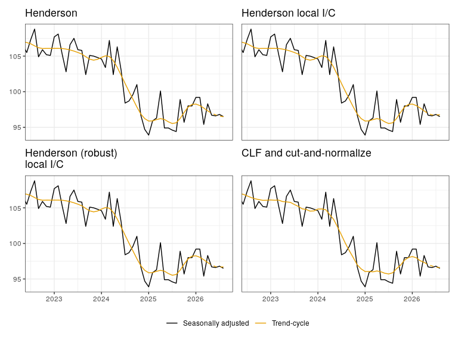

**confint**

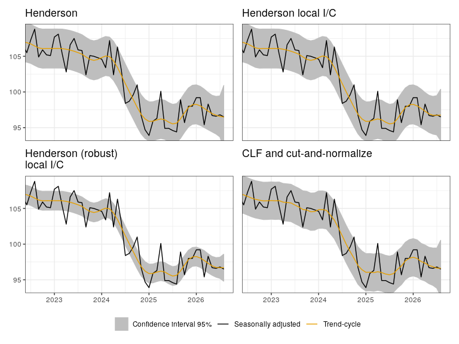

**lollypop**

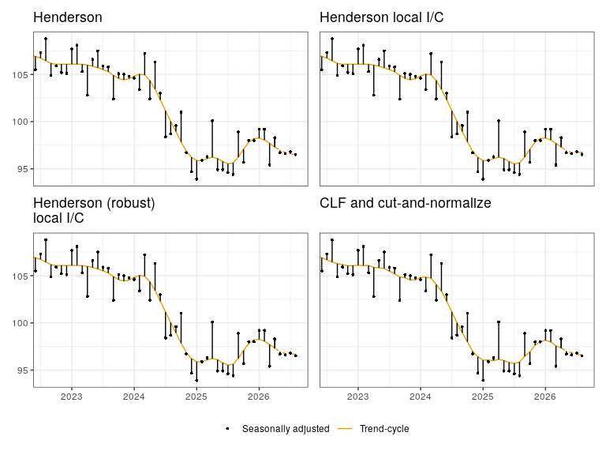

**implicit_forecasts**

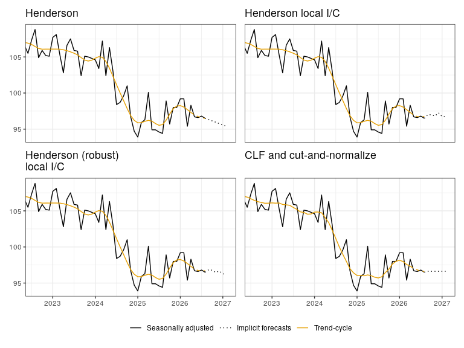

## 4.2 Comparaison des méthodes

**Dernières années**

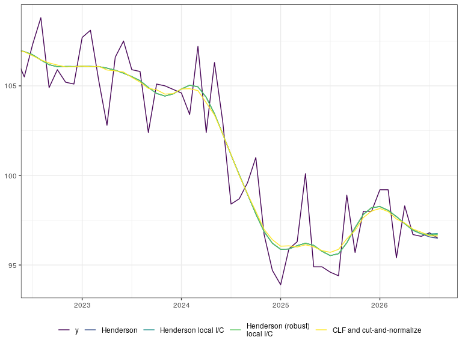

**Ensemble**

[interactive chart not shown]

## 4.3 Analyse des révisions

**Série CVS-CJO**

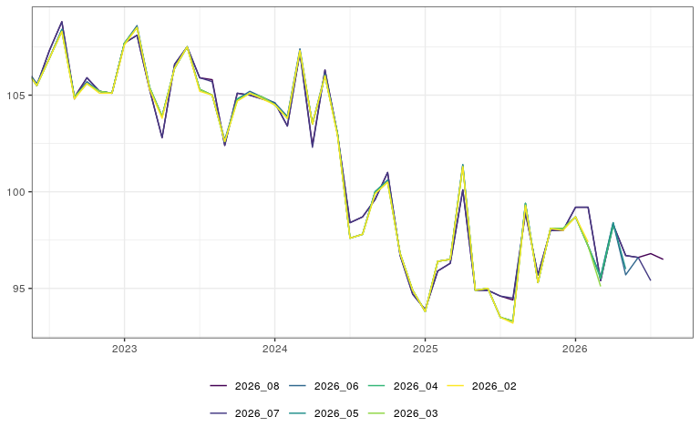

**Henderson**

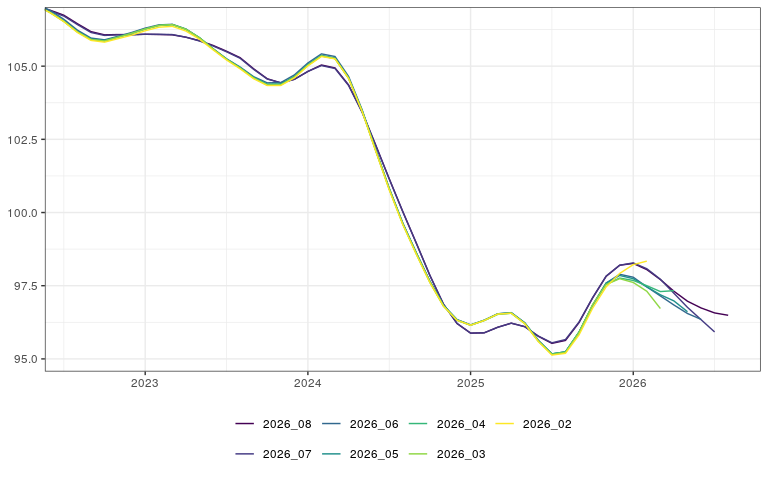

**Henderson local I/C**

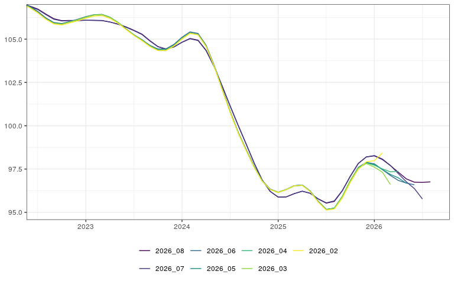

**Henderson (robust) local I/C**

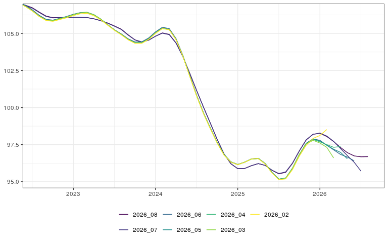

**CLF and cut-and-normalize**

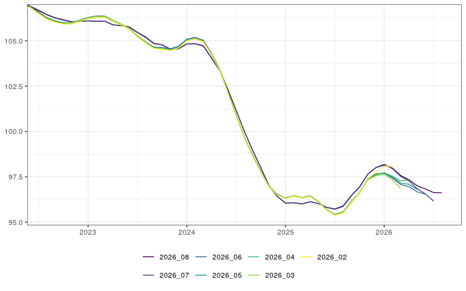

## 4.4 Analyse des révisions

### Révisions

|  | Methods | 2026-08 | 2026-07 | 2026-06 | 2026-05 | 2026-04 | 2026-03 | 2026-02 | 2026-01 | 2025-12 | 2025-11 | 2025-10 | 2025-09 | 2025-08 | 2025-07 | 2025-06 | 2025-05 | 2025-04 | 2025-03 | 2025-02 | 2025-01 | 2024-12 | 2024-11 | 2024-10 | 2024-09 | 2024-08 | 2024-07 | 2024-06 | 2024-05 | … |
| --- | --- | --- | --- | --- | --- | --- | --- | --- | --- | --- | --- | --- | --- | --- | --- | --- | --- | --- | --- | --- | --- | --- | --- | --- | --- | --- | --- | --- | --- | --- |
| 2026-08 | Série CVS-CJO | 96.5 | 96.8 | 96.6 | 96.7 | 98.3 | 95.4 | 99.2 | 99.2 | 98 | 98 | 95.7 | 98.9 | 94.4 | 94.6 | 94.9 | 94.9 | 100.1 | 96.3 | 95.9 | 93.9 | 94.7 | 96.7 | 101 | 99.6 | 98.7 | 98.4 | 103 | 106.3 | … |
| 2026-07 | Série CVS-CJO |  | 95.4 | 96.6 | 96.7 | 98.3 | 95.4 | 99.2 | 99.2 | 98 | 98 | 95.7 | 98.9 | 94.5 | 94.6 | 94.9 | 94.9 | 100.1 | 96.3 | 95.9 | 93.9 | 94.7 | 96.7 | 101 | 99.6 | 98.7 | 98.4 | 103 | 106.3 | … |
| 2026-06 | Série CVS-CJO |  |  | 96.6 | 95.7 | 98.4 | 95.6 | 97.2 | 98.7 | 98.1 | 98.1 | 95.3 | 99.4 | 93.3 | 93.5 | 95 | 94.9 | 101.4 | 96.5 | 96.4 | 93.8 | 94.9 | 96.8 | 100.6 | 100 | 97.8 | 97.6 | 103 | 106.1 | … |
| 2026-05 | Série CVS-CJO |  |  |  | 96 | 98.4 | 95.6 | 97.2 | 98.7 | 98.1 | 98.1 | 95.3 | 99.4 | 93.3 | 93.5 | 95 | 94.9 | 101.4 | 96.5 | 96.4 | 93.8 | 94.9 | 96.8 | 100.6 | 100 | 97.8 | 97.6 | 103 | 106 | … |
| 2026-04 | Série CVS-CJO |  |  |  |  | 98.2 | 95.5 | 97.2 | 98.7 | 98.1 | 98.1 | 95.3 | 99.4 | 93.3 | 93.5 | 95 | 94.9 | 101.3 | 96.5 | 96.4 | 93.8 | 94.9 | 96.8 | 100.5 | 100 | 97.8 | 97.6 | 103 | 106 | … |
| 2026-03 | Série CVS-CJO |  |  |  |  |  | 95.1 | 97.2 | 98.7 | 98.1 | 98.1 | 95.3 | 99.3 | 93.3 | 93.5 | 95 | 94.9 | 101.3 | 96.5 | 96.4 | 93.8 | 94.9 | 96.8 | 100.5 | 99.9 | 97.8 | 97.6 | 103 | 106 | … |
| 2026-02 | Série CVS-CJO |  |  |  |  |  |  | 97.4 | 98.7 | 98 | 98.1 | 95.3 | 99.3 | 93.2 | 93.5 | 95 | 94.9 | 101.3 | 96.5 | 96.4 | 93.8 | 94.9 | 96.8 | 100.5 | 99.9 | 97.8 | 97.6 | 102.9 | 106 | … |
| 2026-08 | Henderson | 96.491818740716 | 96.5701388993248 | 96.742269730154 | 96.9675189935074 | 97.3113335966781 | 97.7063969469684 | 98.0541081209812 | 98.2594903548464 | 98.2018099547511 | 97.822451774232 | 97.0785901405096 | 96.2386818290069 | 95.6325494165277 | 95.5250952607764 | 95.7673017385092 | 96.0978566325315 | 96.2154620147654 | 96.0801321743272 | 95.8940045248869 | 95.8752083829483 | 96.2149321266968 | 96.865092879257 | 97.849351035961 | 98.9466420576328 | 100.028048344844 | 101.154322457728 | 102.308442486306 | 103.438003095975 | … |
| 2026-07 | Henderson |  | 95.918303129325 | 96.3354932520585 | 96.7605224899321 | 97.2400118320535 | 97.7190606314905 | 98.0826054456475 | 98.2837937604192 | 98.2018099547511 | 97.8290009526078 | 97.0933257918552 | 96.2601155036914 | 95.6565551321743 | 95.5465289354608 | 95.7820373898547 | 96.1044058109074 | 96.2154620147654 | 96.0773457966182 | 95.8920695403667 | 95.8752083829483 | 96.2149321266968 | 96.865092879257 | 97.8512860204811 | 98.9494284353417 | 100.028048344844 | 101.147773279352 | 102.293706834961 | 103.416569421291 | … |
| 2026-06 | Henderson |  |  | 96.3488071391466 | 96.5494549056961 | 96.8443486988147 | 97.1508822316752 | 97.46199945391 | 97.7916381538796 | 97.8888485353656 | 97.5929090259586 | 96.8263634198619 | 95.9147118361515 | 95.2396106215766 | 95.1742081447964 | 95.6250476303882 | 96.2277149321267 | 96.5789890450107 | 96.5432424386759 | 96.3212550607287 | 96.163443677066 | 96.3373303167421 | 96.8318885448916 | 97.6519647535127 | 98.6216539652298 | 99.6386341986187 | 100.827119552274 | 102.154280781138 | 103.513705644201 | … |

[output cut: 25 more lines]

### Révisions à la dernière estimation

|  | Meth | Last date | 2026-07 | 2026-06 | 2026-05 | 2026-04 | 2026-03 | 2026-02 | 2026-01 | 2025-12 | 2025-11 | 2025-10 | 2025-09 | 2025-08 | 2025-07 | 2025-06 | 2025-05 | 2025-04 | 2025-03 | 2025-02 | 2025-01 | 2024-12 | 2024-11 | 2024-10 | 2024-09 | 2024-08 | 2024-07 | 2024-06 | 2024-05 | … |
| --- | --- | --- | --- | --- | --- | --- | --- | --- | --- | --- | --- | --- | --- | --- | --- | --- | --- | --- | --- | --- | --- | --- | --- | --- | --- | --- | --- | --- | --- | --- |
| Due to revisions on SA | CLF and cut-and-normalize | 2026-07 | 0.5124183006535787 | 0.3290000000000362 | 0.2034188034187849 | 0.09351944167497095 | 0.04197292069633818 | -0.006913339824691889 | -0.03710000000000946 | -0.003100000000003433 | -0.006699999999995043 | -0.01359999999999673 | -0.01879999999999882 | -0.02240000000000464 | -0.01879999999999882 | -0.01359999999999673 | -0.006699999999995043 | -0.003100000000003433 | 0.0007000000000090267 | 0.002700000000004366 | 0 | 0 | 0 | -0.002700000000004366 | -0.0007000000000090267 | 0.003100000000003433 | 0.006699999999995043 | 0.01359999999999673 | 0.01879999999999882 | … |
| Due to update of TC model | CLF and cut-and-normalize | 2026-07 | -0.04143218954249051 | -0.05663034188033578 | -0.03616884389568042 | -0.02610678602486871 | 0.007236528620850891 | 0.0390251217136921 | 0 | 0 | 0 | 0 | 0 | 0 | 0 | 0 | 0 | 0 | 0 | 0 | 0 | 0 | 0 | 0 | 0 | 0 | 0 | 0 | 0 | … |
| Total | CLF and cut-and-normalize | 2026-07 | 0.4709861111110882 | 0.2723696581197004 | 0.1672499595231045 | 0.06741265565010224 | 0.04920944931718907 | 0.03211178188900021 | -0.03710000000000946 | -0.003100000000003433 | -0.006699999999995043 | -0.01359999999999673 | -0.01879999999999882 | -0.02240000000000464 | -0.01879999999999882 | -0.01359999999999673 | -0.006699999999995043 | -0.003100000000003433 | 0.0007000000000090267 | 0.002700000000004366 | 0 | 0 | 0 | -0.002700000000004366 | -0.0007000000000090267 | 0.003100000000003433 | 0.006699999999995043 | 0.01359999999999673 | 0.01879999999999882 | … |
| Due to revisions on SA | CLF and cut-and-normalize | 2026-06 |  | 0.3630718954248522 | 0.4136249999999819 | 0.4490384615384642 | 0.5157527417746621 | 0.506479690522255 | 0.4153846153845677 | 0.351300000000009 | 0.2439999999999998 | 0.3181000000000012 | 0.3140000000000072 | 0.3072999999999979 | 0.2848000000000042 | 0.1153000000000048 | -0.1089999999999947 | -0.319500000000005 | -0.3448999999999955 | -0.3910999999999945 | -0.2796000000000021 | -0.113900000000001 | 0.02350000000001273 | 0.2003999999999877 | 0.2678999999999974 | 0.3252999999999986 | 0.2672000000000025 | 0.1263000000000005 | -0.06000000000000227 | … |
| Due to update of TC model | CLF and cut-and-normalize | 2026-06 |  | -0.08420060331825141 | -0.07721585244267715 | -0.06696444808146396 | -0.01630561091796778 | 0.04677911025143544 | 0.03558636806232585 | 0 | 0 | 0 | 0 | 0 | 0 | 0 | 0 | 0 | 0 | 0 | 0 | 0 | 0 | 0 | 0 | 0 | 0 | 0 | 0 | … |
| Total | CLF and cut-and-normalize | 2026-06 |  | 0.2788712921066008 | 0.3364091475573048 | 0.3820740134570002 | 0.4994471308566943 | 0.5532588007736905 | 0.4509709834468936 | 0.351300000000009 | 0.2439999999999998 | 0.3181000000000012 | 0.3140000000000072 | 0.3072999999999979 | 0.2848000000000042 | 0.1153000000000048 | -0.1089999999999947 | -0.319500000000005 | -0.3448999999999955 | -0.3910999999999945 | -0.2796000000000021 | -0.113900000000001 | 0.02350000000001273 | 0.2003999999999877 | 0.2678999999999974 | 0.3252999999999986 | 0.2672000000000025 | 0.1263000000000005 | -0.06000000000000227 | … |
| Due to revisions on SA | CLF and cut-and-normalize | 2026-05 |  |  | 0.4308823529411541 | 0.4548749999999444 | 0.5090811965812065 | 0.5020937188435113 | 0.4035783365570609 | 0.3441090555014057 | 0.2520999999999987 | 0.3181000000000012 | 0.3140000000000072 | 0.3072999999999979 | 0.2848000000000042 | 0.1153000000000048 | -0.1089999999999947 | -0.319500000000005 | -0.3448999999999955 | -0.3910999999999945 | -0.2796000000000021 | -0.113900000000001 | 0.02080000000000837 | 0.1996999999999929 | 0.2682999999999964 | 0.3312999999999988 | 0.2811999999999983 | 0.1510999999999996 | -0.02360000000000184 | … |
| Due to update of TC model | CLF and cut-and-normalize | 2026-05 |  |  | -0.2254348066910552 | -0.2049441489361499 | -0.0868305744888147 | 0.005436889331988937 | 0.04586305609284125 | 0.037179552093491 | 0 | 0 | 0 | 0 | 0 | 0 | 0 | 0 | 0 | 0 | 0 | 0 | 0 | 0 | 0 | 0 | 0 | 0 | 0 | … |
| Total | CLF and cut-and-normalize | 2026-05 |  |  | 0.2054475462500989 | 0.2499308510637945 | 0.4222506220923918 | 0.5075306081755002 | 0.4494413926499021 | 0.3812886075948967 | 0.2520999999999987 | 0.3181000000000012 | 0.3140000000000072 | 0.3072999999999979 | 0.2848000000000042 | 0.1153000000000048 | -0.1089999999999947 | -0.319500000000005 | -0.3448999999999955 | -0.3910999999999945 | -0.2796000000000021 | -0.113900000000001 | 0.02080000000000837 | 0.1996999999999929 | 0.2682999999999964 | 0.3312999999999988 | 0.2811999999999983 | 0.1510999999999996 | -0.02360000000000184 | … |
| Due to revisions on SA | CLF and cut-and-normalize | 2026-04 |  |  |  | 0.4834967320261399 | 0.5516249999999587 | 0.5370726495726359 | 0.4213359920239412 | 0.3589941972920911 | 0.2655306718598069 | 0.3092999999999932 | 0.310600000000008 | 0.3104000000000013 | 0.2914999999999992 | 0.1289000000000016 | -0.09019999999999584 | -0.2998000000000047 | -0.3267999999999915 | -0.3743999999999943 | -0.2661999999999978 | -0.09720000000000084 | 0.03890000000001237 | 0.2193999999999932 | 0.2870999999999952 | 0.3422000000000054 | 0.2871999999999986 | 0.1572999999999922 | -0.01760000000000161 | … |

[output cut: 62 more lines]

## 4.5 Statistiques générales

|  | I/C ratio | MCD | Length |
| --- | --- | --- | --- |
| Henderson | 2.45 | 4 | 13 |
| Henderson local I/C | 2.44 | 4 | 13 |
| Henderson (robust) local I/C | 1.45 | 2 | 13 |
| CLF and cut-and-normalize | 2.63 | 4 | 13 |

**Outliers**:

- *Level shift* (LS): April 2020, June 2020, and December 2020

# 5 Indicateur synthétique du climat des affaires dans les activités immobilières (L)

## 5.1 Par graphique

**normal**

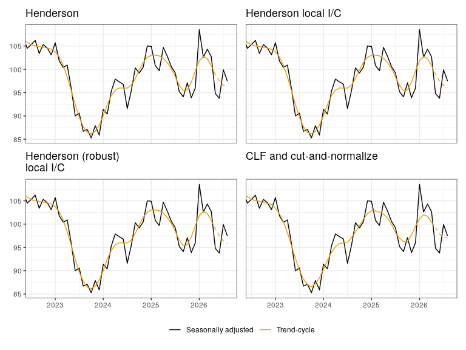

**confint**

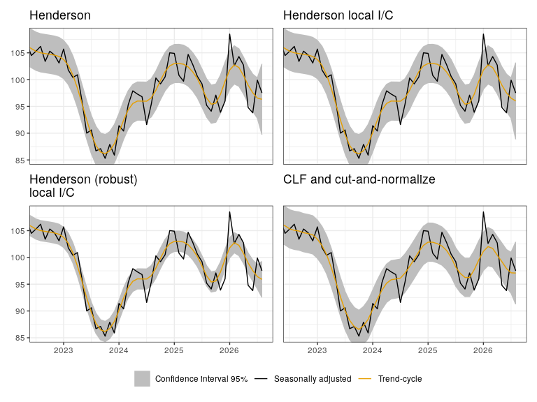

**lollypop**

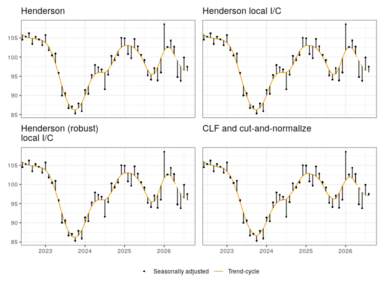

**implicit_forecasts**

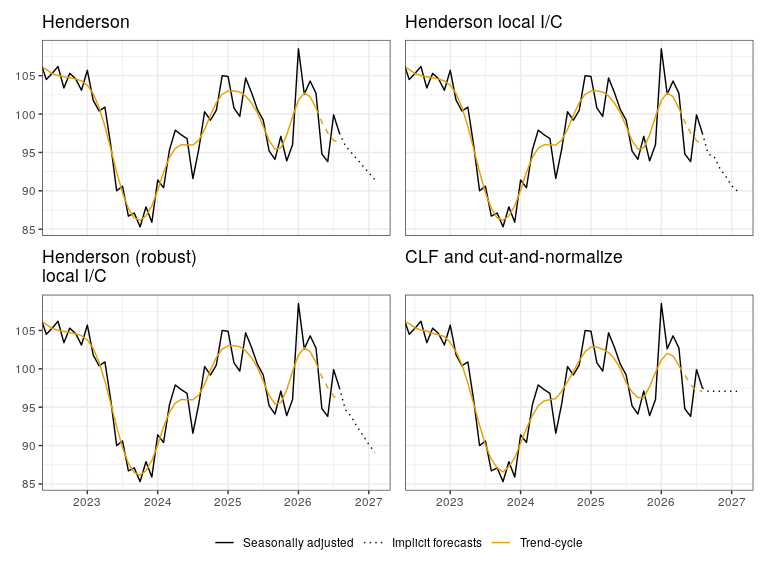

## 5.2 Comparaison des méthodes

**Dernières années**

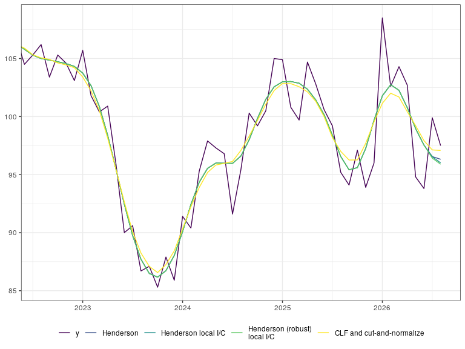

**Ensemble**

[interactive chart not shown]

## 5.3 Analyse des révisions

**Série CVS-CJO**

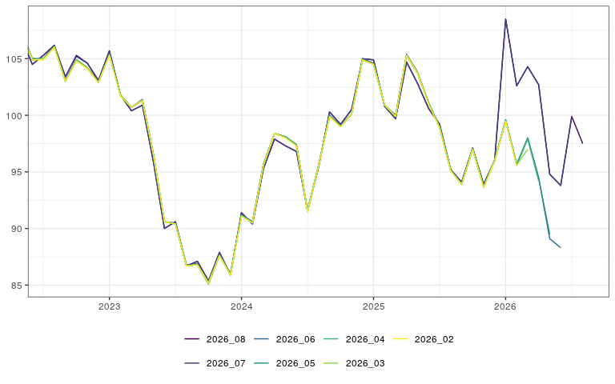

**Henderson**

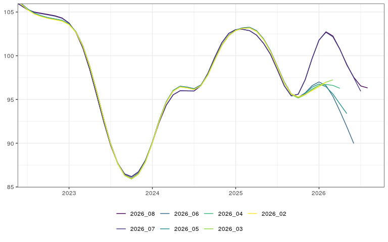

**Henderson local I/C**

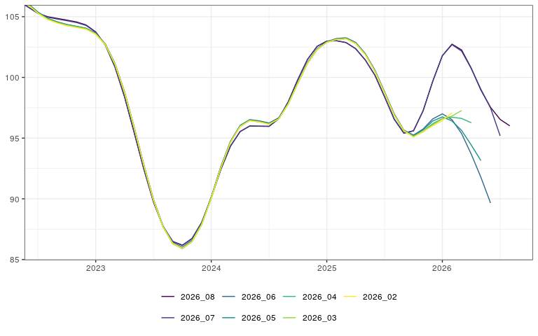

**Henderson (robust) local I/C**

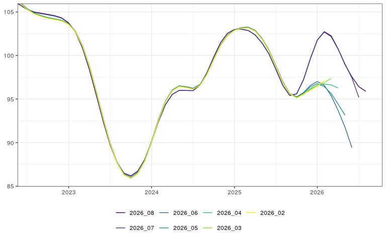

**CLF and cut-and-normalize**

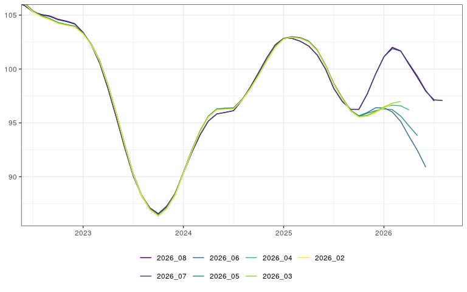

## 5.4 Analyse des révisions

### Révisions

|  | Methods | 2026-08 | 2026-07 | 2026-06 | 2026-05 | 2026-04 | 2026-03 | 2026-02 | 2026-01 | 2025-12 | 2025-11 | 2025-10 | 2025-09 | 2025-08 | 2025-07 | 2025-06 | 2025-05 | 2025-04 | 2025-03 | 2025-02 | 2025-01 | 2024-12 | 2024-11 | 2024-10 | 2024-09 | 2024-08 | 2024-07 | 2024-06 | 2024-05 | … |
| --- | --- | --- | --- | --- | --- | --- | --- | --- | --- | --- | --- | --- | --- | --- | --- | --- | --- | --- | --- | --- | --- | --- | --- | --- | --- | --- | --- | --- | --- | --- |
| 2026-08 | Série CVS-CJO | 97.5 | 99.9 | 93.8 | 94.8 | 102.7 | 104.3 | 102.6 | 108.5 | 96 | 93.9 | 97.1 | 94.1 | 95.2 | 99.2 | 100.6 | 102.8 | 104.7 | 99.7 | 100.8 | 104.9 | 105 | 100.5 | 99.2 | 100.3 | 95.4 | 91.6 | 96.8 | 97.3 | … |
| 2026-07 | Série CVS-CJO |  | 99.9 | 93.8 | 94.8 | 102.7 | 104.3 | 102.6 | 108.5 | 96 | 93.9 | 97.1 | 94.1 | 95.2 | 99.2 | 100.6 | 102.8 | 104.7 | 99.7 | 100.8 | 104.9 | 105 | 100.5 | 99.2 | 100.3 | 95.4 | 91.6 | 96.8 | 97.3 | … |
| 2026-06 | Série CVS-CJO |  |  | 88.3 | 89.1 | 94.5 | 98 | 95.7 | 99.6 | 96.1 | 93.7 | 97.1 | 94 | 95.2 | 99 | 101.1 | 103.8 | 105.4 | 100 | 100.9 | 104.6 | 105 | 100.1 | 99.1 | 100 | 95.6 | 91.6 | 97.4 | 98.1 | … |
| 2026-05 | Série CVS-CJO |  |  |  | 89.5 | 94.4 | 98 | 95.6 | 99.6 | 96 | 93.7 | 97 | 93.9 | 95.2 | 99 | 101.1 | 103.7 | 105.3 | 100 | 100.9 | 104.5 | 104.9 | 100.1 | 99 | 100 | 95.5 | 91.5 | 97.4 | 98.1 | … |
| 2026-04 | Série CVS-CJO |  |  |  |  | 94.2 | 97.9 | 95.6 | 99.5 | 96 | 93.7 | 97 | 93.9 | 95.1 | 98.9 | 101.1 | 103.7 | 105.3 | 99.9 | 100.9 | 104.5 | 104.9 | 100.1 | 99 | 99.9 | 95.5 | 91.5 | 97.3 | 98.1 | … |
| 2026-03 | Série CVS-CJO |  |  |  |  |  | 97 | 95.6 | 99.5 | 96 | 93.6 | 97 | 93.9 | 95.1 | 98.9 | 101 | 103.7 | 105.3 | 99.9 | 100.9 | 104.5 | 104.9 | 100.1 | 99 | 99.9 | 95.5 | 91.5 | 97.3 | 98 | … |
| 2026-02 | Série CVS-CJO |  |  |  |  |  |  | 95.5 | 99.5 | 96 | 93.6 | 97 | 93.9 | 95.1 | 98.9 | 101 | 103.7 | 105.3 | 99.9 | 100.9 | 104.5 | 104.9 | 100.1 | 99 | 99.9 | 95.5 | 91.5 | 97.3 | 98 | … |
| 2026-08 | Henderson | 96.3205789138987 | 96.5521528412236 | 97.5425876422486 | 98.9534913372685 | 100.759168837264 | 102.258419855092 | 102.74447487497 | 101.785990712074 | 99.6807275541796 | 97.250261967135 | 95.5983210288164 | 95.4130328649678 | 96.5623541319362 | 98.3986961181234 | 100.16600976423 | 101.433930697785 | 102.360984758276 | 102.872630388188 | 103.019296261015 | 102.993796141939 | 102.564050964515 | 101.493897356513 | 99.8424267682782 | 98.0013396046678 | 96.5908073350798 | 95.9678792569659 | 95.9790069064063 | 95.9951357466063 | … |
| 2026-07 | Henderson |  | 95.9432511103533 | 97.5013591456069 | 99.0162644462755 | 100.726241125461 | 102.164174571796 | 102.684158534862 | 101.785990712074 | 99.6807275541796 | 97.250261967135 | 95.5983210288164 | 95.4130328649678 | 96.5623541319362 | 98.3986961181234 | 100.16600976423 | 101.433930697785 | 102.360984758276 | 102.872630388188 | 103.019296261015 | 102.993796141939 | 102.564050964515 | 101.493897356513 | 99.8424267682782 | 98.0013396046678 | 96.5908073350798 | 95.9678792569659 | 95.9790069064063 | 95.9951357466063 | … |
| 2026-06 | Henderson |  |  | 89.9722861517635 | 91.8792679122243 | 93.6825156737356 | 95.363696984842 | 96.5896036718443 | 97.0125018226665 | 96.5795070254823 | 95.7510776375327 | 95.2455822814956 | 95.6582341033579 | 96.9953322219576 | 98.8087639914265 | 100.585752560133 | 101.964086687306 | 102.879197427959 | 103.26253869969 | 103.195808525839 | 102.95213741367 | 102.364866634913 | 101.236621814718 | 99.6243391283639 | 97.9008454393903 | 96.6658013812813 | 96.2433257918552 | 96.4189926172898 | 96.5197011193141 | … |

[output cut: 25 more lines]

### Révisions à la dernière estimation

|  | Meth | Last date | 2026-07 | 2026-06 | 2026-05 | 2026-04 | 2026-03 | 2026-02 | 2026-01 | 2025-12 | 2025-11 | 2025-10 | 2025-09 | 2025-08 | 2025-07 | 2025-06 | 2025-05 | 2025-04 | 2025-03 | 2025-02 | 2025-01 | 2024-12 | 2024-11 | 2024-10 | 2024-09 | 2024-08 | 2024-07 | 2024-06 | 2024-05 | … |
| --- | --- | --- | --- | --- | --- | --- | --- | --- | --- | --- | --- | --- | --- | --- | --- | --- | --- | --- | --- | --- | --- | --- | --- | --- | --- | --- | --- | --- | --- | --- |
| Due to revisions on SA | CLF and cut-and-normalize | 2026-07 | -2.842170943040401e-14 | -2.842170943040401e-14 | -1.4210854715202e-14 | -1.56319401867222e-13 | -5.968558980384842e-13 | 1.13686837721616e-13 | 0 | 0 | 0 | 0 | 0 | 0 | 0 | 0 | 0 | 0 | 0 | 0 | 0 | 0 | 0 | 0 | 0 | 0 | 0 | 0 | 0 | … |
| Due to update of TC model | CLF and cut-and-normalize | 2026-07 | 0.114696895424828 | -0.07250427350426492 | -0.1226657633935844 | -0.09007050415485196 | 0.02832779932160179 | 0.1186185978578891 | 0 | 0 | 0 | 0 | 0 | 0 | 0 | 0 | 0 | 0 | 0 | 0 | 0 | 0 | 0 | 0 | 0 | 0 | 0 | 0 | 0 | … |
| Total | CLF and cut-and-normalize | 2026-07 | 0.1146968954247995 | -0.07250427350429334 | -0.1226657633935986 | -0.09007050415500828 | 0.02832779932100493 | 0.1186185978580028 | 0 | 0 | 0 | 0 | 0 | 0 | 0 | 0 | 0 | 0 | 0 | 0 | 0 | 0 | 0 | 0 | 0 | 0 | 0 | 0 | 0 | … |
| Due to revisions on SA | CLF and cut-and-normalize | 2026-06 |  | 6.52810457516334 | 6.803375000000003 | 6.806623931623534 | 6.58115653040835 | 5.870309477756223 | 4.71402142161638 | 3.133500000000012 | 1.733000000000004 | 0.6113 | 0.07609999999999673 | -0.3337999999999965 | -0.468599999999995 | -0.3749000000000109 | -0.473700000000008 | -0.4555000000000007 | -0.3391999999999911 | -0.1682999999999879 | -0.0003999999999990678 | 0.1403999999999996 | 0.2182999999999993 | 0.165300000000002 | 0.07019999999999982 | -0.08990000000000009 | -0.2573000000000008 | -0.3913000000000011 | -0.4679000000000002 | … |
| Due to update of TC model | CLF and cut-and-normalize | 2026-06 |  | 0.5114630467571573 | -0.02684097706880095 | -0.1333261006133313 | -0.02594825067154716 | 0.1321127659574728 | 0.03259454722491739 | 0 | 0 | 0 | 0 | 0 | 0 | 0 | 0 | 0 | 0 | 0 | 0 | 0 | 0 | 0 | 0 | 0 | 0 | 0 | 0 | … |
| Total | CLF and cut-and-normalize | 2026-06 |  | 7.039567621920497 | 6.776534022931202 | 6.673297831010203 | 6.555208279736803 | 6.002422243713696 | 4.746615968841297 | 3.133500000000012 | 1.733000000000004 | 0.6113 | 0.07609999999999673 | -0.3337999999999965 | -0.468599999999995 | -0.3749000000000109 | -0.473700000000008 | -0.4555000000000007 | -0.3391999999999911 | -0.1682999999999879 | -0.0003999999999990678 | 0.1403999999999996 | 0.2182999999999993 | 0.165300000000002 | 0.07019999999999982 | -0.08990000000000009 | -0.2573000000000008 | -0.3913000000000011 | -0.4679000000000002 | … |
| Due to revisions on SA | CLF and cut-and-normalize | 2026-05 |  |  | 7.097875816993465 | 6.9802499999996 | 6.644123931623497 | 5.906879361914264 | 4.759671179883938 | 3.256280428432348 | 1.798300000000012 | 0.6631 | 0.1256999999999948 | -0.2912000000000035 | -0.4313999999999965 | -0.3388000000000062 | -0.4277000000000015 | -0.4106000000000023 | -0.2899000000000029 | -0.1151999999999873 | 0.05389999999999873 | 0.1999999999999886 | 0.2758999999999929 | 0.2256 | 0.1312000000000069 | -0.03269999999999129 | -0.2128000000000014 | -0.3585000000000065 | -0.4483000000000033 | … |
| Due to update of TC model | CLF and cut-and-normalize | 2026-05 |  |  | -1.698105682951166 | -1.280408365570608 | -0.5921819214540847 | -0.1176114656031615 | 0.08206305609284925 | 0.1507819863680595 | 0 | 0 | 0 | 0 | 0 | 0 | 0 | 0 | 0 | 0 | 0 | 0 | 0 | 0 | 0 | 0 | 0 | 0 | 0 | … |
| Total | CLF and cut-and-normalize | 2026-05 |  |  | 5.399770134042299 | 5.699841634428992 | 6.051942010169412 | 5.789267896311102 | 4.841734235976787 | 3.407062414800407 | 1.798300000000012 | 0.6631 | 0.1256999999999948 | -0.2912000000000035 | -0.4313999999999965 | -0.3388000000000062 | -0.4277000000000015 | -0.4106000000000023 | -0.2899000000000029 | -0.1151999999999873 | 0.05389999999999873 | 0.1999999999999886 | 0.2758999999999929 | 0.2256 | 0.1312000000000069 | -0.03269999999999129 | -0.2128000000000014 | -0.3585000000000065 | -0.4483000000000033 | … |
| Due to revisions on SA | CLF and cut-and-normalize | 2026-04 |  |  |  | 7.611274509803494 | 6.964624999999529 | 6.016666666666637 | 4.788833499501521 | 3.303094777562848 | 1.914800389483972 | 0.6839999999999975 | 0.1557999999999993 | -0.2514000000000038 | -0.3897999999999939 | -0.2997000000000014 | -0.3937999999999988 | -0.382000000000005 | -0.267799999999994 | -0.1004999999999967 | 0.06790000000000873 | 0.2106999999999886 | 0.2918999999999983 | 0.2468000000000075 | 0.1548999999999978 | -0.00369999999999493 | -0.1807000000000016 | -0.3230000000000075 | -0.406400000000005 | … |

[output cut: 62 more lines]

## 5.5 Statistiques générales

|  | I/C ratio | MCD | Length |
| --- | --- | --- | --- |
| Henderson | 2.01 | 3 | 13 |
| Henderson local I/C | 2.00 | 3 | 13 |
| Henderson (robust) local I/C | 1.41 | 2 | 13 |
| CLF and cut-and-normalize | 2.28 | 3 | 13 |

**Outliers**:

- *Level shift* (LS): November 2017, March 2020, April 2020, June 2020, July 2020, March 2021, and May 2021

# 6 Indicateur synthétique du climat des affaires dans les activités spécialisées, scientifiques et techniques (M)

## 6.1 Par graphique

**normal**

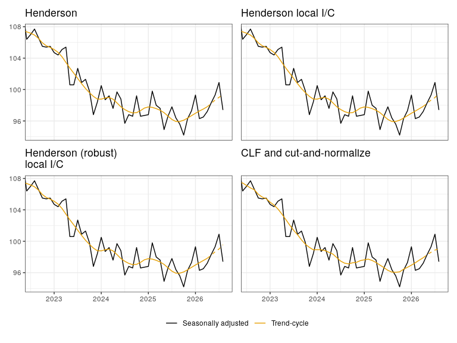

**confint**

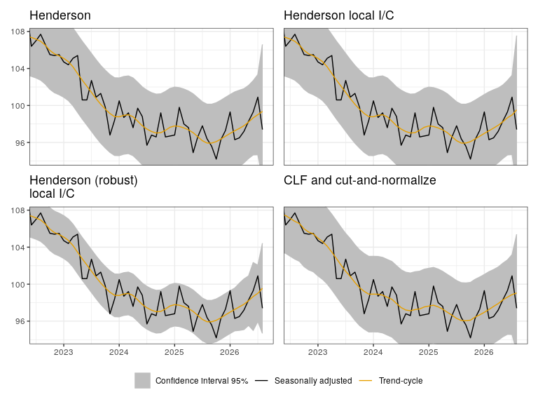

**lollypop**

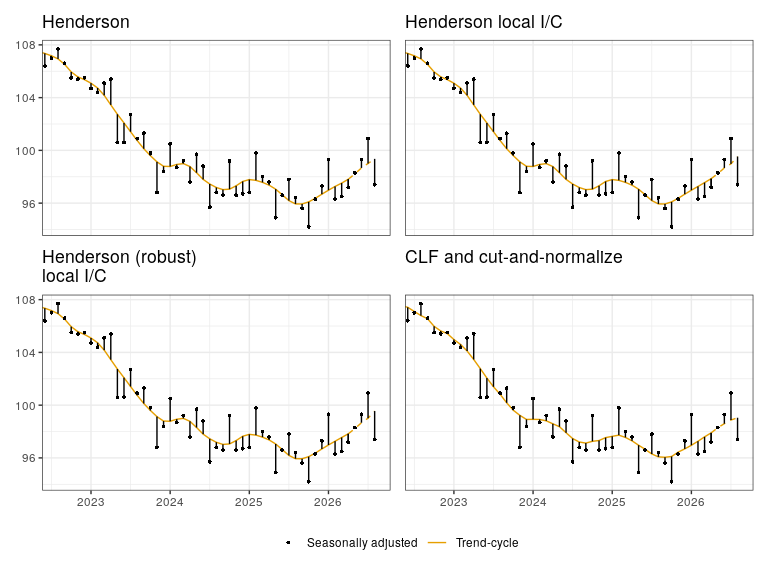

**implicit_forecasts**

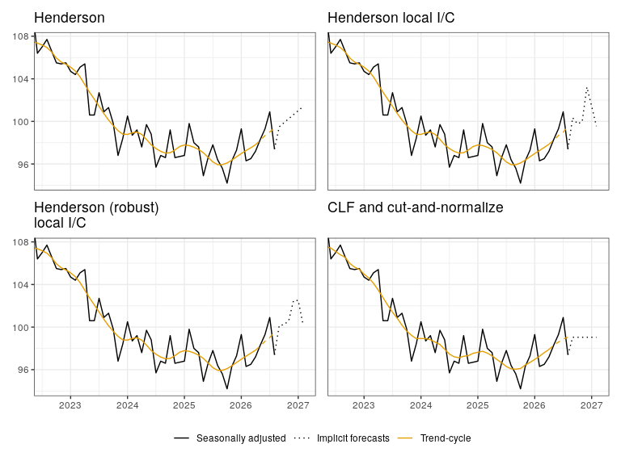

## 6.2 Comparaison des méthodes

**Dernières années**

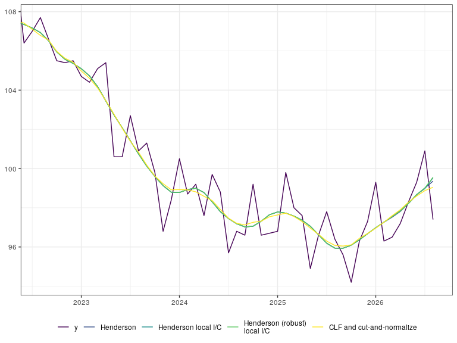

**Ensemble**

[interactive chart not shown]

## 6.3 Analyse des révisions

**Série CVS-CJO**

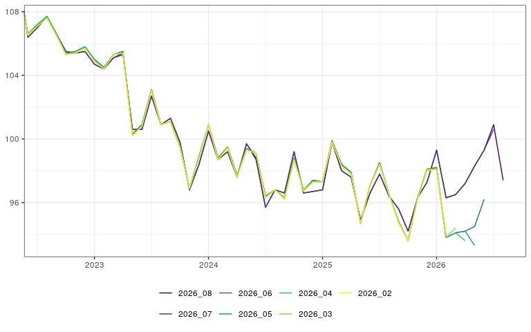

**Henderson**

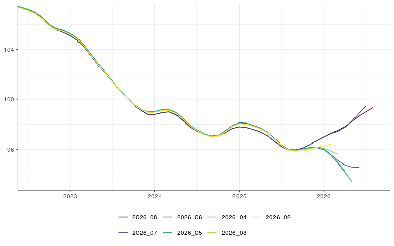

**Henderson local I/C**

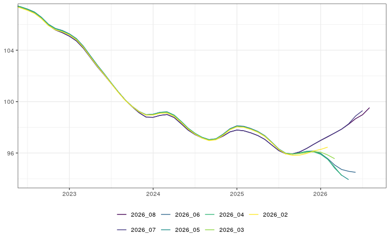

**Henderson (robust) local I/C**

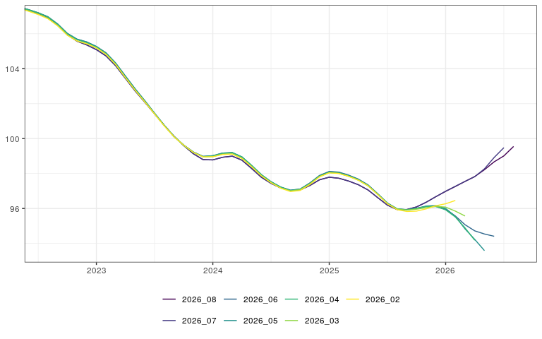

**CLF and cut-and-normalize**

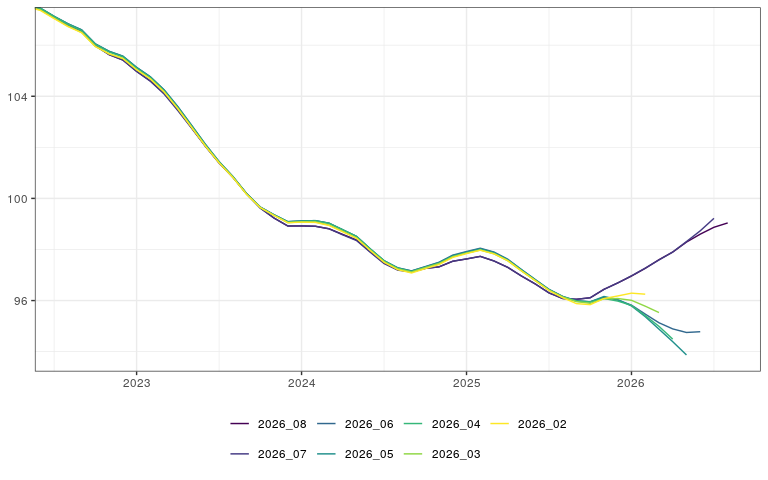

## 6.4 Analyse des révisions

### Révisions

|  | Methods | 2026-08 | 2026-07 | 2026-06 | 2026-05 | 2026-04 | 2026-03 | 2026-02 | 2026-01 | 2025-12 | 2025-11 | 2025-10 | 2025-09 | 2025-08 | 2025-07 | 2025-06 | 2025-05 | 2025-04 | 2025-03 | 2025-02 | 2025-01 | 2024-12 | 2024-11 | 2024-10 | 2024-09 | 2024-08 | 2024-07 | 2024-06 | 2024-05 | … |
| --- | --- | --- | --- | --- | --- | --- | --- | --- | --- | --- | --- | --- | --- | --- | --- | --- | --- | --- | --- | --- | --- | --- | --- | --- | --- | --- | --- | --- | --- | --- |
| 2026-08 | Série CVS-CJO | 97.4 | 100.9 | 99.3 | 98.3 | 97.2 | 96.5 | 96.3 | 99.3 | 97.3 | 96.3 | 94.2 | 95.6 | 96.4 | 97.8 | 96.6 | 94.9 | 97.6 | 98 | 99.8 | 96.8 | 96.7 | 96.6 | 99.2 | 96.6 | 96.8 | 95.7 | 98.8 | 99.7 | … |
| 2026-07 | Série CVS-CJO |  | 100.6 | 99.3 | 98.3 | 97.2 | 96.5 | 96.3 | 99.3 | 97.3 | 96.3 | 94.2 | 95.6 | 96.4 | 97.8 | 96.6 | 94.9 | 97.6 | 98 | 99.8 | 96.8 | 96.7 | 96.6 | 99.2 | 96.6 | 96.8 | 95.7 | 98.7 | 99.7 | … |
| 2026-06 | Série CVS-CJO |  |  | 96.2 | 94.5 | 94.2 | 94.1 | 93.8 | 98.2 | 98.1 | 96.3 | 93.6 | 94.8 | 96.5 | 98.5 | 97.1 | 94.7 | 97.9 | 98.4 | 99.9 | 97.3 | 97.4 | 96.8 | 98.8 | 96.3 | 96.8 | 96.4 | 99.1 | 99.4 | … |
| 2026-05 | Série CVS-CJO |  |  |  | 93.3 | 94.2 | 94.1 | 93.8 | 98.2 | 98.1 | 96.3 | 93.6 | 94.8 | 96.5 | 98.5 | 97.1 | 94.7 | 97.9 | 98.4 | 99.8 | 97.3 | 97.4 | 96.8 | 98.8 | 96.3 | 96.8 | 96.4 | 99.1 | 99.4 | … |
| 2026-04 | Série CVS-CJO |  |  |  |  | 93.6 | 94.1 | 93.8 | 98.1 | 98.1 | 96.3 | 93.6 | 94.8 | 96.5 | 98.4 | 97.1 | 94.7 | 97.9 | 98.3 | 99.8 | 97.3 | 97.3 | 96.8 | 98.7 | 96.3 | 96.8 | 96.4 | 99.1 | 99.4 | … |
| 2026-03 | Série CVS-CJO |  |  |  |  |  | 94.4 | 93.8 | 98.1 | 98.1 | 96.3 | 93.6 | 94.8 | 96.5 | 98.4 | 97.1 | 94.7 | 97.8 | 98.3 | 99.8 | 97.3 | 97.3 | 96.8 | 98.7 | 96.3 | 96.8 | 96.3 | 99.1 | 99.3 | … |
| 2026-02 | Série CVS-CJO |  |  |  |  |  |  | 94 | 98.1 | 98 | 96.2 | 93.6 | 94.7 | 96.5 | 98.4 | 97.1 | 94.7 | 97.8 | 98.3 | 99.8 | 97.3 | 97.3 | 96.7 | 98.7 | 96.2 | 96.8 | 96.3 | 99.1 | 99.3 | … |
| 2026-08 | Henderson | 99.3581651068947 | 99.0059279917967 | 98.6675724567001 | 98.2189031492957 | 97.809805879094 | 97.518905895147 | 97.2649499880924 | 96.9809776137176 | 96.6794951178852 | 96.3646522981662 | 96.0935163134079 | 95.9364729697547 | 95.9398606811146 | 96.190866873065 | 96.6242200523934 | 97.0557335079781 | 97.3629792807811 | 97.5742855441772 | 97.7284412955465 | 97.7860145272684 | 97.6431055013098 | 97.3145987139795 | 97.0584246249107 | 97.023725887116 | 97.1848713979519 | 97.4502976899262 | 97.8013396046678 | 98.3047213622291 | … |
| 2026-07 | Henderson |  | 99.4927254279365 | 98.8989891665564 | 98.2734070865805 | 97.7530842505317 | 97.4394861134911 | 97.2315152655896 | 96.9867825672779 | 96.6794951178852 | 96.3646522981662 | 96.0935163134079 | 95.9364729697547 | 95.9398606811146 | 96.190866873065 | 96.6242200523934 | 97.0557335079781 | 97.3629792807811 | 97.5742855441772 | 97.7284412955465 | 97.7860145272684 | 97.64504048583 | 97.3173850916885 | 97.0584246249107 | 97.0171767087402 | 97.1701357466063 | 97.4288640152417 | 97.7773338890212 | 98.2832876875447 | … |
| 2026-06 | Henderson |  |  | 94.5407249720414 | 94.5634135882843 | 94.7186656938934 | 95.0738560297955 | 95.574306151512 | 95.9547280930339 | 96.1060788282924 | 96.1174208144796 | 96.0091271731365 | 95.9255477494641 | 95.9805429864253 | 96.3070373898547 | 96.8412062395809 | 97.347725648964 | 97.6809359371279 | 97.9084841628959 | 98.0796261014527 | 98.1183555608478 | 97.8941116932603 | 97.4558883067397 | 97.112181471779 | 97.0449690402477 | 97.2231602762563 | 97.5348713979519 | 97.9338890211955 | 98.4637532745892 | … |

[output cut: 25 more lines]

### Révisions à la dernière estimation

|  | Meth | Last date | 2026-07 | 2026-06 | 2026-05 | 2026-04 | 2026-03 | 2026-02 | 2026-01 | 2025-12 | 2025-11 | 2025-10 | 2025-09 | 2025-08 | 2025-07 | 2025-06 | 2025-05 | 2025-04 | 2025-03 | 2025-02 | 2025-01 | 2024-12 | 2024-11 | 2024-10 | 2024-09 | 2024-08 | 2024-07 | 2024-06 | 2024-05 | … |
| --- | --- | --- | --- | --- | --- | --- | --- | --- | --- | --- | --- | --- | --- | --- | --- | --- | --- | --- | --- | --- | --- | --- | --- | --- | --- | --- | --- | --- | --- | --- |
| Due to revisions on SA | CLF and cut-and-normalize | 2026-07 | 0.1098039215686839 | 0.07049999999996714 | 0.04358974358973455 | 0.02003988035889392 | 0.008994197291997352 | -0.00204479065237706 | -0.008099999999998886 | 0 | 0 | 0 | 0 | 0 | 0 | 0 | 0 | 0 | 0 | 0 | 0 | -0.002700000000004366 | -0.0007000000000090267 | 0.003100000000003433 | 0.006700000000009254 | 0.01359999999999673 | 0.01879999999999882 | 0.02240000000000464 | 0.01879999999999882 | … |
| Due to update of TC model | CLF and cut-and-normalize | 2026-07 | -0.4526053921568831 | -0.2035277777777651 | -0.06354526165094398 | -0.01544766088579763 | 0.001323642691801297 | -0.003622784810119128 | 0 | 0 | 0 | 0 | 0 | 0 | 0 | 0 | 0 | 0 | 0 | 0 | 0 | 0 | 0 | 0 | 0 | 0 | 0 | 0 | 0 | … |
| Total | CLF and cut-and-normalize | 2026-07 | -0.3428014705881992 | -0.133027777777798 | -0.01995551806120943 | 0.004592219473096293 | 0.01031783998379865 | -0.005667575462496188 | -0.008099999999998886 | 0 | 0 | 0 | 0 | 0 | 0 | 0 | 0 | 0 | 0 | 0 | 0 | -0.002700000000004366 | -0.0007000000000090267 | 0.003100000000003433 | 0.006700000000009254 | 0.01359999999999673 | 0.01879999999999882 | 0.02240000000000464 | 0.01879999999999882 | … |
| Due to revisions on SA | CLF and cut-and-normalize | 2026-06 |  | 3.380718954248351 | 3.16449999999999 | 2.811858974358927 | 2.359222333001 | 1.821663442940121 | 1.240603700097353 | 0.6616000000000071 | 0.3087999999999909 | 0.1600999999999999 | 0.06180000000000518 | -0.08039999999999736 | -0.1358000000000033 | -0.1740999999999957 | -0.2531999999999925 | -0.3228000000000009 | -0.3457000000000079 | -0.3252000000000095 | -0.2804999999999893 | -0.2385000000000019 | -0.1784999999999997 | -0.06810000000000116 | -0.03289999999999793 | -0.06870000000000687 | -0.09709999999999752 | -0.1101000000000028 | -0.144999999999996 | … |
| Due to update of TC model | CLF and cut-and-normalize | 2026-06 |  | 0.4413398692810517 | 0.369736789631105 | 0.1982040122997688 | 0.1034970065460925 | -0.02822553191491295 | -0.1035648490749566 | 0 | 0 | 0 | 0 | 0 | 0 | 0 | 0 | 0 | 0 | 0 | 0 | 0 | 0 | 0 | 0 | 0 | 0 | 0 | 0 | … |
| Total | CLF and cut-and-normalize | 2026-06 |  | 3.822058823529403 | 3.534236789631095 | 3.010062986658696 | 2.462719339547093 | 1.793437911025208 | 1.137038851022396 | 0.6616000000000071 | 0.3087999999999909 | 0.1600999999999999 | 0.06180000000000518 | -0.08039999999999736 | -0.1358000000000033 | -0.1740999999999957 | -0.2531999999999925 | -0.3228000000000009 | -0.3457000000000079 | -0.3252000000000095 | -0.2804999999999893 | -0.2385000000000019 | -0.1784999999999997 | -0.06810000000000116 | -0.03289999999999793 | -0.06870000000000687 | -0.09709999999999752 | -0.1101000000000028 | -0.144999999999996 | … |
| Due to revisions on SA | CLF and cut-and-normalize | 2026-05 |  |  | 3.623529411764693 | 3.044874999999962 | 2.480555555555483 | 1.862313060817584 | 1.289168278529985 | 0.7175267770204243 | 0.2763999999999953 | 0.1600999999999999 | 0.06180000000000518 | -0.08309999999998752 | -0.1364999999999981 | -0.1710000000000065 | -0.2464999999999975 | -0.3091999999999899 | -0.3269000000000091 | -0.3028000000000048 | -0.2616999999999905 | -0.224899999999991 | -0.1718000000000046 | -0.06499999999999773 | -0.03359999999999275 | -0.07139999999999702 | -0.09709999999999752 | -0.1101000000000028 | -0.144999999999996 | … |
| Due to update of TC model | CLF and cut-and-normalize | 2026-05 |  |  | 0.7942727373435048 | 0.4699315764023311 | 0.2329140971546195 | 0.03388494516451601 | -0.1187003868471805 | -0.06871460564752851 | 0 | 0 | 0 | 0 | 0 | 0 | 0 | 0 | 0 | 0 | 0 | 0 | 0 | 0 | 0 | 0 | 0 | 0 | 0 | … |
| Total | CLF and cut-and-normalize | 2026-05 |  |  | 4.417802149108198 | 3.514806576402293 | 2.713469652710103 | 1.8961980059821 | 1.170467891682804 | 0.6488121713728958 | 0.2763999999999953 | 0.1600999999999999 | 0.06180000000000518 | -0.08309999999998752 | -0.1364999999999981 | -0.1710000000000065 | -0.2464999999999975 | -0.3091999999999899 | -0.3269000000000091 | -0.3028000000000048 | -0.2616999999999905 | -0.224899999999991 | -0.1718000000000046 | -0.06499999999999773 | -0.03359999999999275 | -0.07139999999999702 | -0.09709999999999752 | -0.1101000000000028 | -0.144999999999996 | … |
| Due to revisions on SA | CLF and cut-and-normalize | 2026-04 |  |  |  | 2.674836601307192 | 2.210249999999959 | 1.744978632478663 | 1.234197407776662 | 0.7820116054159172 | 0.4127555988315095 | 0.1572999999999922 | 0.07580000000000098 | -0.06569999999999254 | -0.1137000000000086 | -0.1482000000000028 | -0.2199999999999989 | -0.283299999999997 | -0.2954000000000008 | -0.2680000000000007 | -0.2252999999999901 | -0.1821999999999946 | -0.1311000000000035 | -0.02969999999999118 | -0.01079999999998904 | -0.05470000000001107 | -0.0911000000000115 | -0.112400000000008 | -0.1463999999999999 | … |

[output cut: 62 more lines]

## 6.5 Statistiques générales

|  | I/C ratio | MCD | Length |
| --- | --- | --- | --- |
| Henderson | 2.13 | 3 | 13 |
| Henderson local I/C | 2.13 | 3 | 13 |
| Henderson (robust) local I/C | 1.31 | 2 | 13 |
| CLF and cut-and-normalize | 2.36 | 4 | 13 |

**Outliers**:

- *Additive outlier* (AO) : May 2020, June 2020, and November 2020
- *Level shift* (LS): March 2020, April 2020, June 2020, and May 2021